# Analysis of LSE Accommodation Halls 2024/5: A Value Based Approach

- 1 Introduction
  - 1.1 Research questions
- 2 Data Acquisition and Cleaning
  - 2.1 Data across halls
  - 2.2 Data within halls
- 3 Data Analysis
  - 3.1 Q1: How do the accommodation options across all halls differ?
    - 3.1.1 Comparison across halls
    - 3.1.2 Comparison within halls
  - 3.2 Q2: Which accommodation option offers the best Value for Money?
  - 3.3 Q3: Do any factors play a significant role in determining the price of an accommodation option?
- 4 Conclusion
  - 4.1 Limitations
- 5 Reference

# Introduction

For incoming LSE students, one of the biggest decisions to make is choosing the right accommodation. This is a stressful and intimidating decision as it can have a major impact on their academic performance, social life, and financial situation. Moreover, there is currently no data-driven analysis available that concurrently evaluates different parameters of LSE accommodations. It can be extremely confusing and time-consuming for students to simultaneously compare and contrast multiple PDFs and websites when evaluating accommodation options.

Thus, this project intends to deliver a multidimensional value assessment model to assist students in making well-informed accommodation choices without compromising their needs and preferences by analysing various factors such as price, commute time, facilities, and type of rooms available. This would make the information easily comparable, especially with the scoring system.

### Research questions

1. How do accommodation options across all halls differ?
2. Which accommodation option offers the best value for money?
3. Do any factors play a significant role in determining the price of an accommodation option?

# Data Acquisition and Cleaning

In order to provide a complete analysis of LSE accommodation halls, we need to first collect information about each hall, then collect information about each type of room available in each hall as this corresponds to different prices (i.e rent per week). To do this, we extract the necessary information from each hall's webpage and create two dataframes:

- Data across halls
  - This dataframe contains information about the facilities each hall has to offer (including catering), the time taken to travel from the hall to the LSE campus, and the type of students that are eligible to stay in the hall.
- Data within halls
  - This dataframe contains information about the types of rooms students are able to rent in each hall and the corresponding prices.

## Data across halls

First, we create a function to extract the name and URL of each accommodation hall. This can be obtained through the [LSE webpage](https://www.lse.ac.uk/student-life/accommodation/search-accommodation), which lists all LSE halls.

```python
import requests
from bs4 import BeautifulSoup
import pandas as pd
import re

pd.options.display.max_rows = None

# The base URL for the LSE accommodation site
base_url = "https://www.lse.ac.uk/student-life/accommodation/search-accommodation"
accommodation_url_pattern = "/student-life/accommodation/halls/"

# Function to scrape the first page
def scrape_page(page_url):
    response = requests.get(page_url)
    response.raise_for_status()
    soup = BeautifulSoup(response.text, 'lxml')
    accommodation_links = soup.select('.link')
    links = [link['href'] for link in accommodation_links if accommodation_url_pattern in link['href']]
    return links

# Display both the pages' urls
page_links = scrape_page(base_url) # First page
page_links.extend(scrape_page(base_url + '?pageIndex=2'))  # Second page

# Print the links
for link in page_links:
    print(link)
```

```
http://www.lse.ac.uk/student-life/accommodation/halls/urbanest-westminster-bridge/home.aspx
http://www.lse.ac.uk/student-life/accommodation/halls/lilian-knowles-house/home.aspx
http://www.lse.ac.uk/student-life/accommodation/halls/college-hall/home.aspx
http://www.lse.ac.uk/student-life/accommodation/halls/international-hall/home.aspx
http://www.lse.ac.uk/student-life/accommodation/halls/butlers-wharf-residence/home.aspx
http://www.lse.ac.uk/student-life/accommodation/halls/bankside-house/home.aspx
http://www.lse.ac.uk/student-life/accommodation/halls/carr-saunders-hall/home.aspx
http://www.lse.ac.uk/student-life/accommodation/halls/connaught-hall/home.aspx
http://www.lse.ac.uk/student-life/accommodation/halls/high-holborn-residence/home.aspx
http://www.lse.ac.uk/student-life/accommodation/halls/passfield-hall/home.aspx
http://www.lse.ac.uk/student-life/accommodation/halls/nutford-house/home.aspx
http://www.lse.ac.uk/student-life/accommodation/halls/rosebery-hall/home.aspx
http://www.lse.ac.uk/student-life/accommodation/halls/the-garden-halls/home.aspx
http://www.lse.ac.uk/student-life/accommodation/halls/sidney-webb-house/home.aspx
```

Next, we create functions to extract the necessary information from each hall's webpage. This information includes:

- Name of accommodation hall
- Eligible students
- Time taken to travel to LSE (by foot, bicycle, and public transport)
- Whether or not catering is provided
- Facilities available (e.g Study Space, Computer Room, Printing Facilities, Bicycle Storage, Common Room, Projector/Cinema)

```python
# Function to extract and format the hall name from the URL
def extract_hall_name(url):
    name_parts = url.split('/')[-2].replace('-', ' ').title()
    return name_parts

# Function to extract the eligibility information
def extract_eligibility(eligibility_paragraph):
    # Normalize the text to handle different capitalizations
    text = eligibility_paragraph

    # Check for each specific eligibility phrase and return the corresponding classification
    if 'Graduate and undergraduate students' in text or 'Postgraduate and undergraduate students' in text:
        return 'UG/PG'
    elif 'Postgraduate students only' in text:
        return 'PG'
    elif 'Graduate students only' in text:
        return 'PG'
    elif 'Most of the LSE quota in this hall will be allocated to undergraduate students' in text:
        return 'UG priority'
    elif 'Undergraduate students first' in text:
        return 'UG priority'
    elif 'Undergraduate students only' in text:
        return 'UG'
    elif 'Undergraduate students.' in text and 'If there are still single rooms available in late summer' in text:
        return 'UG priority'
    else:
        return 'Other'

# Function to scrape eligibility for a single accommodation link
def scrape_eligibility(link):
    response = requests.get(link)
    response.raise_for_status()
    soup = BeautifulSoup(response.text, 'lxml')
    eligibility_paragraph = soup.select_one('p:-soup-contains("Who can")')
    if eligibility_paragraph:
        eligibility_text = eligibility_paragraph.get_text(separator='|')
        return extract_eligibility(eligibility_text)
    else:
        return 'Unknown'

# Function to extract numerical travel times from a text string
def extract_travel_time(text):
    digits = ''.join(filter(str.isdigit, text))
    return int(digits) if digits else None

# Function to scrape facilities for a single accommodation link
def scrape_facilities(link):
    response = requests.get(link)
    response.raise_for_status()
    soup = BeautifulSoup(response.text, 'lxml')
    facilities = soup.find_all(class_="ataGlance__name")
    facility_list = [facility.get_text(strip=True) for facility in facilities]
    catering = 'Y' if 'Catered' in facility_list else 'N'
    study_space = 'Y' if 'Quiet study space' in facility_list else 'N'
    computer_room = 'Y' if 'Computer room' in facility_list else 'N'
    printing_facilities = 'Y' if 'Printing facilities' in facility_list else 'N'
    bicycle_storage = 'Y' if 'Bicycle storage' in facility_list else 'N'
    common_room = 'Y' if 'Common room' in facility_list else 'N'
    projector_cinema = 'Y' if 'Projector/Cinema room' in facility_list else 'N'
    return catering, study_space, computer_room, printing_facilities, bicycle_storage, common_room, projector_cinema

# Function to scrape travel times for a single accommodation link
def scrape_travel_times(link):
    response = requests.get(link)
    response.raise_for_status()
    soup = BeautifulSoup(response.text, 'lxml')
    travel_info_paragraph = soup.select_one('p:-soup-contains("Travel time to campus")')
    if travel_info_paragraph:
        travel_times = travel_info_paragraph.get_text(separator='|').split('|')
        return {
            'Time taken (Foot)': extract_travel_time(travel_times[1]) if len(travel_times) > 1 else None,
            'Time taken (Bike)': extract_travel_time(travel_times[2]) if len(travel_times) > 2 else None,
            'Time taken (Public Transport)': extract_travel_time(travel_times[3]) if len(travel_times) > 3 else None
        }
    else:
        return {'Time taken (Foot)': None, 'Time taken (Bike)': None, 'Time taken (Public Transport)': None}

for link in page_links:
    print(f"Scraping data for: {link}")
    hall_name = extract_hall_name(link)
    print("Hall Name:", hall_name)

    eligibility = scrape_eligibility(link)
    print("Eligibility:", eligibility)

    facilities = scrape_facilities(link)
    print("Facilities:", facilities)

    travel_times = scrape_travel_times(link)
    print("Travel Times:", travel_times)

    print()
```

```
Scraping data for: http://www.lse.ac.uk/student-life/accommodation/halls/urbanest-westminster-bridge/home.aspx
Hall Name: Urbanest Westminster Bridge
Eligibility: UG/PG
Facilities: ('N', 'Y', 'Y', 'Y', 'Y', 'Y', 'Y')
Travel Times: {'Time taken (Foot)': 25, 'Time taken (Bike)': 9, 'Time taken (Public Transport)': 11}

Scraping data for: http://www.lse.ac.uk/student-life/accommodation/halls/lilian-knowles-house/home.aspx
Hall Name: Lilian Knowles House
Eligibility: PG
Facilities: ('N', 'N', 'Y', 'Y', 'Y', 'Y', 'N')
Travel Times: {'Time taken (Foot)': 45, 'Time taken (Bike)': 19, 'Time taken (Public Transport)': 25}

Scraping data for: http://www.lse.ac.uk/student-life/accommodation/halls/college-hall/home.aspx
Hall Name: College Hall
Eligibility: UG priority
Facilities: ('Y', 'N', 'N', 'N', 'Y', 'Y', 'N')
Travel Times: {'Time taken (Foot)': 22, 'Time taken (Bike)': 8, 'Time taken (Public Transport)': 16}

Scraping data for: http://www.lse.ac.uk/student-life/accommodation/halls/international-hall/home.aspx
Hall Name: International Hall
Eligibility: UG priority
Facilities: ('Y', 'Y', 'N', 'N', 'Y', 'Y', 'Y')
Travel Times: {'Time taken (Foot)': 19, 'Time taken (Bike)': 8, 'Time taken (Public Transport)': 13}

Scraping data for: http://www.lse.ac.uk/student-life/accommodation/halls/butlers-wharf-residence/home.aspx
Hall Name: Butlers Wharf Residence
Eligibility: PG
Facilities: ('N', 'N', 'Y', 'Y', 'Y', 'Y', 'N')
Travel Times: {'Time taken (Foot)': 51, 'Time taken (Bike)': 22, 'Time taken (Public Transport)': 34}

Scraping data for: http://www.lse.ac.uk/student-life/accommodation/halls/bankside-house/home.aspx
Hall Name: Bankside House
Eligibility: UG priority
Facilities: ('Y', 'Y', 'Y', 'Y', 'Y', 'Y', 'N')
Travel Times: {'Time taken (Foot)': 27, 'Time taken (Bike)': 13, 'Time taken (Public Transport)': 24}

Scraping data for: http://www.lse.ac.uk/student-life/accommodation/halls/carr-saunders-hall/home.aspx
Hall Name: Carr Saunders Hall
Eligibility: UG
Facilities: ('Y', 'N', 'Y', 'Y', 'Y', 'Y', 'Y')
```

[output cut: 28 more lines]

```
Eligibility: UG priority
Facilities: ('Y', 'N', 'Y', 'Y', 'Y', 'Y', 'N')
Travel Times: {'Time taken (Foot)': 27, 'Time taken (Bike)': 12, 'Time taken (Public Transport)': 19}

Scraping data for: http://www.lse.ac.uk/student-life/accommodation/halls/the-garden-halls/home.aspx
Hall Name: The Garden Halls
Eligibility: UG priority
Facilities: ('Y', 'Y', 'N', 'N', 'Y', 'Y', 'Y')
Travel Times: {'Time taken (Foot)': 25, 'Time taken (Bike)': 9, 'Time taken (Public Transport)': 16}

Scraping data for: http://www.lse.ac.uk/student-life/accommodation/halls/sidney-webb-house/home.aspx
Hall Name: Sidney Webb House
Eligibility: UG/PG
Facilities: ('N', 'N', 'Y', 'Y', 'Y', 'Y', 'N')
Travel Times: {'Time taken (Foot)': 45, 'Time taken (Bike)': 19, 'Time taken (Public Transport)': 24}
```

Finally, using the functions created, we gather all the links of LSE halls. For each link corresponding to each hall, we extract the necessary information and store this in a list of dictionaries, which is then converted into a DataFrame.

```python
# Initialize a list to store the data
accommodation_data = []

# Loop over each link and scrape the travel times and facilities, then store the results in the list
for link in page_links:
    travel_times = scrape_travel_times(link)
    catering, study_space, computer_room, printing_facilities, bicycle_storage, common_room, projector_cinema = scrape_facilities(link)
    eligibility = scrape_eligibility(link)
    travel_times.update({
        'Catering': catering,
        'Study Space': study_space,
        'Computer Room': computer_room,
        'Printing Facilities': printing_facilities,
        'Bicycle Storage': bicycle_storage,
        'Common Room': common_room,
        'Projector/Cinema': projector_cinema,
        'Name': extract_hall_name(link),
        'Eligibility': eligibility
    })
    accommodation_data.append(travel_times)

# Convert the list of dictionaries to a DataFrame
accom_data = pd.DataFrame(accommodation_data)

accom_data
```

|  | Time taken (Foot) | Time taken (Bike) | Time taken (Public Transport) | Catering | Study Space | Computer Room | Printing Facilities | Bicycle Storage | Common Room | Projector/Cinema | Name | Eligibility |
| --- | --- | --- | --- | --- | --- | --- | --- | --- | --- | --- | --- | --- |
| 0 | 25 | 9 | 11 | N | Y | Y | Y | Y | Y | Y | Urbanest Westminster Bridge | UG/PG |
| 1 | 45 | 19 | 25 | N | N | Y | Y | Y | Y | N | Lilian Knowles House | PG |
| 2 | 22 | 8 | 16 | Y | N | N | N | Y | Y | N | College Hall | UG priority |
| 3 | 19 | 8 | 13 | Y | Y | N | N | Y | Y | Y | International Hall | UG priority |
| 4 | 51 | 22 | 34 | N | N | Y | Y | Y | Y | N | Butlers Wharf Residence | PG |
| 5 | 27 | 13 | 24 | Y | Y | Y | Y | Y | Y | N | Bankside House | UG priority |
| 6 | 28 | 11 | 23 | Y | N | Y | Y | Y | Y | Y | Carr Saunders Hall | UG |
| 7 | 21 | 8 | 14 | Y | Y | N | N | Y | Y | N | Connaught Hall | UG priority |
| 8 | 11 | 4 | 10 | N | N | Y | Y | N | Y | N | High Holborn Residence | UG/PG |
| 9 | 23 | 10 | 15 | Y | N | Y | Y | Y | Y | N | Passfield Hall | UG |
| 10 | 50 | 21 | 27 | Y | Y | N | N | Y | Y | N | Nutford House | UG priority |
| 11 | 27 | 12 | 19 | Y | N | Y | Y | Y | Y | N | Rosebery Hall | UG priority |
| 12 | 25 | 9 | 16 | Y | Y | N | N | Y | Y | Y | The Garden Halls | UG priority |
| 13 | 45 | 19 | 24 | N | N | Y | Y | Y | Y | N | Sidney Webb House | UG/PG |

For neatness and readability, we:

- Convert the columns containing information about time taken to travel to LSE (i.e 'Time taken (Foot)', 'Time taken (Bike)', 'Time taken (Public Transport)') to float and round them to 1 decimal place
- Reorder the columns
- Reset the index to start at 1 instead of 0

```python
# Convert the columns to float and round to 1 decimal place
accom_data['Time taken (Foot)'] = accom_data['Time taken (Foot)'].astype(float).round(1)
accom_data['Time taken (Bike)'] = accom_data['Time taken (Bike)'].astype(float).round(1)
accom_data['Time taken (Public Transport)'] = accom_data['Time taken (Public Transport)'].astype(float).round(1)

# Define the new column order & reorder the columns
column_order = [
    'Name', 'Eligibility', 'Time taken (Foot)', 'Time taken (Bike)', 'Time taken (Public Transport)', 'Catering', 'Study Space',
    'Computer Room', 'Printing Facilities', 'Bicycle Storage', 'Common Room', 'Projector/Cinema'
]
accom_data = accom_data[column_order]

# Reset the index to start at 1 instead of 0
accom_data.index = accom_data.index + 1

accom_data
```

|  | Name | Eligibility | Time taken (Foot) | Time taken (Bike) | Time taken (Public Transport) | Catering | Study Space | Computer Room | Printing Facilities | Bicycle Storage | Common Room | Projector/Cinema |
| --- | --- | --- | --- | --- | --- | --- | --- | --- | --- | --- | --- | --- |
| 1 | Urbanest Westminster Bridge | UG/PG | 25.0 | 9.0 | 11.0 | N | Y | Y | Y | Y | Y | Y |
| 2 | Lilian Knowles House | PG | 45.0 | 19.0 | 25.0 | N | N | Y | Y | Y | Y | N |
| 3 | College Hall | UG priority | 22.0 | 8.0 | 16.0 | Y | N | N | N | Y | Y | N |
| 4 | International Hall | UG priority | 19.0 | 8.0 | 13.0 | Y | Y | N | N | Y | Y | Y |
| 5 | Butlers Wharf Residence | PG | 51.0 | 22.0 | 34.0 | N | N | Y | Y | Y | Y | N |
| 6 | Bankside House | UG priority | 27.0 | 13.0 | 24.0 | Y | Y | Y | Y | Y | Y | N |
| 7 | Carr Saunders Hall | UG | 28.0 | 11.0 | 23.0 | Y | N | Y | Y | Y | Y | Y |
| 8 | Connaught Hall | UG priority | 21.0 | 8.0 | 14.0 | Y | Y | N | N | Y | Y | N |
| 9 | High Holborn Residence | UG/PG | 11.0 | 4.0 | 10.0 | N | N | Y | Y | N | Y | N |
| 10 | Passfield Hall | UG | 23.0 | 10.0 | 15.0 | Y | N | Y | Y | Y | Y | N |
| 11 | Nutford House | UG priority | 50.0 | 21.0 | 27.0 | Y | Y | N | N | Y | Y | N |
| 12 | Rosebery Hall | UG priority | 27.0 | 12.0 | 19.0 | Y | N | Y | Y | Y | Y | N |
| 13 | The Garden Halls | UG priority | 25.0 | 9.0 | 16.0 | Y | Y | N | N | Y | Y | Y |
| 14 | Sidney Webb House | UG/PG | 45.0 | 19.0 | 24.0 | N | N | Y | Y | Y | Y | N |

We have created a Dataframe where we can easily see the type of students that are eligible to stay in the hall, the time taken to travel from the hall to LSE, and the facilities each hall has to offer (including catering). It can be seen there are 14 LSE accommodations halls.

We store this pd.DataFrame to a CSV file in the 'data' folder (without the index).

```python
accom_data.to_csv('data/accommodation_data.csv', index=False)
```

## Data within halls

For each hall, there are several different price points at which a student can rent a room. The different prices correspond to different types of rooms, which are differentiated by multiple factors:

- Number of students living in each room (single: one, twin: two, triple: three) and size of bed
- Type of bathroom (private or shared)
- Room size

Note that LSE corresponds the size of the bed to the room size (i.e a double room is always bigger than a single room).

Each hall's webpage lists all the room types that hall offers, alongside the type of bathroom, room size, and price per week. We create a function to extract the details of each room type and then store this information in a list, which is then converted into a DataFrame.

```python
def scrape_room_details(link):
    response = requests.get(link)
    response.raise_for_status()
    soup = BeautifulSoup(response.text, 'lxml')

    # Find all room entries and their text content
    room_types = [rt.get_text(strip=True) for rt in soup.select('.roomlist__title')]

    # Find the corresponding bathroom types, making sure to skip empty or non-text elements
    bathroom_types = []
    for rt in soup.select('.roomlist__title'):
        bathroom = rt.find_next_sibling('p', class_='roomlist__position')
        if bathroom:
            bathroom_types.append(bathroom.get_text(strip=True))
        else:
            bathroom_types.append('Unknown bathroom')

    # Find all price entries and their text content
    prices = [price.get_text(strip=True) for price in soup.select('.roomataGlance__figure')]

    # Find all size entries and their text content
    size_texts = [size.get_text(strip=True) for size in soup.select('p') if 'Size approx:' in size.get_text()]
    sizes = []
    for st in size_texts:
        # Split the text at 'Size approx: ' and take everything after it
        size_description = st.split('Size approx: ')[1] if 'Size approx: ' in st else 'Unknown size'
        sizes.append(size_description)

    # Assuming each room type has a corresponding bathroom type and size
    num_entries = min(len(room_types), len(bathroom_types), len(prices), len(sizes))
    room_details = []
    for i in range(num_entries):
        room_type = room_types[i]
        bathroom_type = bathroom_types[i]
        price = prices[i]
        size = sizes[i]

        # Append the details for this entry to the room details list
        room_details.append([room_type, bathroom_type, size, price])

    return room_details

# Initialize a list to store room details data
room_data = []

# Use existing loop over each link to also scrape room details
for link in page_links:
    hall_name = link.split('/')[-2].replace('-', ' ').title()  # Extract hall name from link
    room_details = scrape_room_details(link)
    for detail in room_details:
        # Add hall name to the left of the detail
        detail.insert(0, hall_name)
        room_data.append(detail)

# Convert the list of room details to a DataFrame
columns = ['Hall Name', 'Room Type', 'Bathroom Type', 'Room Size', 'Price per Week']
room_df = pd.DataFrame(room_data, columns=columns)

room_df
```

|  | Hall Name | Room Type | Bathroom Type | Room Size | Price per Week |
| --- | --- | --- | --- | --- | --- |
| 0 | Urbanest Westminster Bridge | Single room | Shared bathroom | 8.5m² | 285.23\n\n-£310.76p/wk |
| 1 | Urbanest Westminster Bridge | Single en suite room | Private bathroom | 13.4m² | 286.90\n\n-£346.90p/wk |
| 2 | Urbanest Westminster Bridge | Twin en suite room | Private bathroom | 25.3m² | 227.09\n\n-£240.22p/wk |
| 3 | Urbanest Westminster Bridge | Single studio | Private bathoom | 22.1m² | 420.03\n\n-£458.32p/wk |
| 4 | Lilian Knowles House | Single en suite room | Private bathroom | 8m² to 14m | 198.86\n\n-£242.35p/wk |
| 5 | Lilian Knowles House | Single studio | Private bathroom | 12m² to 22m2 | 263.59\n\n-£303.15p/wk |
| 6 | Lilian Knowles House | One-bed flat | Private bathroom | 21m² to 27m² | 303.15\n\n-£336.43p/wk |
| 7 | College Hall | Single room | Shared bathroom | 12m² | 289.73p/wk |
| 8 | College Hall | Single en suite room | Private bathroom | 14m² | 332.43p/wk |
| 9 | College Hall | Double en suite room | Private bathroom | 17m² | 392.63p/wk |
| 10 | International Hall | Single room | Shared bathroom | 8.95m² | 266.28p/wk |
| 11 | International Hall | Single studio | Private bathroom | 16.4m² to 18.9m² | 294.98\n\n-£301.28p/wk |
| 12 | International Hall | Double studio | Private bathroom | 18.9m² | 321.93p/wk |
| 13 | Butlers Wharf Residence | Single room | Shared bathroom | 10m² | 194.60\n\n-£267.40p/wk |
| 14 | Butlers Wharf Residence | Twin room | Shared bathroom | 14m² | 127.40\n\n-£153.65p/wk |
| 15 | Butlers Wharf Residence | Double room | Shared bathroom | 15m² | 278.95p/wk |
| 16 | Bankside House | Single room | Shared bathroom | 12.5m² | 259.70p/wk |
| 17 | Bankside House | Single en suite room | Private bathroom | 15.66m² to 17.11m² | 277.20\n\n-£297.15p/wk |
| 18 | Bankside House | Twin en suite | Private bathroom | 23.55m² to 25.32m² | 167.65\n\n-£186.20p/wk |
| 19 | Carr Saunders Hall | Single room | Shared bathroom | 9m² | 257.25p/wk |
| 20 | Carr Saunders Hall | Single with queen bed | Shared bathroom | 9m² | 259.35p/wk |
| 21 | Carr Saunders Hall | Twin room | Shared bathroom | 20m² | 173.25p/wk |
| 22 | Carr Saunders Hall | Twin en suite room | Private bathroom | 20m² | 185.50p/wk |
| 23 | Connaught Hall | Single room | Shared bathroom | 9m² | 273.63p/wk |
| 24 | High Holborn Residence | Single room | Shared bathroom | 9.5m² to 12.6m² | 317.80p/wk |
| 25 | High Holborn Residence | Single room with queen bed | Shared bathroom | 9.5m² to 12.6m² | 333.90p/wk |
| 26 | High Holborn Residence | Single en suite room | Private bathroom | 9.5m² to 12.6m² | 333.20p/wk |
| 27 | High Holborn Residence | Twin en suite room | Private bathroom | 16m² | 184.45p/wk |
| 28 | Passfield Hall | Single room | Shared bathroom | 6.2m² to 15.3m² | 231.00\n\n-£274.75p/wk |
| 29 | Passfield Hall | Single en suite room | Private bathroom | 9m² | 287.35p/wk |
| 30 | Passfield Hall | Twin room | Shared bathroom | 17.6m² to 23m² | 158.90\n\n-£166.60p/wk |
| 31 | Passfield Hall | Twin en suite room | Private bathroom | 17.6m² to 23m² | 182.70p/wk |
| 32 | Passfield Hall | Triple room | Shared bathroom | 31 m² | 129.85\n\n-£140.70p/wk |
| 33 | Nutford House | Single room | Shared bathroom | 6.4m² | 236.88\n\n-£263.48p/wk |
| 34 | Rosebery Hall | Single room | Shared bathroom | 10.5m² to 11m² | 247.80\n\n-£263.90p/wk |
| 35 | Rosebery Hall | Twin room | Shared bathroom | 15.5m² to 17.5m² | 168.70p/wk |
| 36 | Rosebery Hall | Twin en suite room | Private bathroom | 17.5m² | 185.50p/wk |
| 37 | The Garden Halls | Single room | Shared bathroom | 10m² | 269.64\n\n-£288.75p/wk |
| 38 | The Garden Halls | Single en suite room | Private bathroom | 12.60m² to 15.50m² | 358.61p/wk |
| 39 | The Garden Halls | Single en suite room | Private bathroom | 13m² to 15m² | 371.70\n\n-£374.08p/wk |
| 40 | The Garden Halls | Single en suite room (Townhouse) | Private bathroom | 9.5m² | 314.16p/wk |
| 41 | Sidney Webb House | Single en suite room | Private bathroom | 10.2m² to 12.1m² | 221.90\n\n-£244.65p/wk |
| 42 | Sidney Webb House | 3 bedroom flat | Shared bathroom and kitchen | 12.1m² | 277.90p/wk |
| 43 | Sidney Webb House | Double en suite room | Private bathroom | 20.1m² | 290.85p/wk |
| 44 | Sidney Webb House | Double studio | Private bathroom | 21.3m² | 336.70p/wk |
| 45 | Sidney Webb House | Queen studio | Private bathroom | 22.5m² | 331.45p/wk |

As seen in the DataFrame, for certain rooms, the Room Size and Price per Week has a range of values. However for data processing, we want to simplify this for calculation purposes. Thus, we take the lower and upper bounds of the range as two distinct values for Room Size that correspond to the Price per Week.

For neatness and readability, we also clean the Room Size and Price per Week columns so that they only display float values.

```python
# This function assumes the 'Room Size' and 'Price per Week' columns are of string type.
def split_ranges(row):
    # Split the room size and price into lower and upper bounds if they contain a hyphen.
    size_parts = row['Room Size'].split(' to ') if ' to ' in row['Room Size'] else [row['Room Size']] * 2
    price_parts = row['Price per Week'].split('-') if '-' in row['Price per Week'] else [row['Price per Week']] * 2

    # Create two new rows for the lower and upper bounds.
    row_lower = row.copy()
    row_upper = row.copy()
    row_lower['Room Size'] = size_parts[0].strip()
    row_lower['Price per Week'] = price_parts[0].strip()
    row_upper['Room Size'] = size_parts[1].strip()
    row_upper['Price per Week'] = price_parts[1].strip()

    return row_lower, row_upper

# New list to store the split rows
split_rows = []

# Iterate over each row and split ranges if necessary
for index, row in room_df.iterrows():
    lower, upper = split_ranges(row)
    split_rows.append(lower)
    # Only append the upper row if the range values are different
    if lower['Room Size'] != upper['Room Size'] or lower['Price per Week'] != upper['Price per Week']:
        split_rows.append(upper)

# Create a new DataFrame from the list of split rows
new_room_df = pd.DataFrame(split_rows, columns=room_df.columns)

# Reset the index to start at 1 instead of 0
new_room_df.reset_index(drop=True, inplace=True)
new_room_df.index += 1

def clean_data(df):
    # Remove 'm^2' from 'Room Size' and update the column name
    df['Room Size'] = df['Room Size'].str.replace('m²', '')
    df['Room Size'] = df['Room Size'].str.replace('m2', '') #specific line for Lilian Knowles House, they have a typing error on their website
    df['Room Size'] = df['Room Size'].str.replace('m', '').astype(float) #specific line for Lilian Knowles House, they have a typing error on their website
    df.rename(columns={'Room Size': 'Room Size (m²)'}, inplace=True)

    # Remove '£' and 'p/wk' from 'Price per Week', convert to float, and update the column name
    df['Price per Week'] = df['Price per Week'].str.replace('£', '').str.replace('p/wk', '').astype(float)
    df.rename(columns={'Price per Week': 'Price (£/week)'}, inplace=True)

    return df

clean_room_df = clean_data(new_room_df)

clean_room_df
```

|  | Hall Name | Room Type | Bathroom Type | Room Size (m²) | Price (£/week) |
| --- | --- | --- | --- | --- | --- |
| 1 | Urbanest Westminster Bridge | Single room | Shared bathroom | 8.50 | 285.23 |
| 2 | Urbanest Westminster Bridge | Single room | Shared bathroom | 8.50 | 310.76 |
| 3 | Urbanest Westminster Bridge | Single en suite room | Private bathroom | 13.40 | 286.90 |
| 4 | Urbanest Westminster Bridge | Single en suite room | Private bathroom | 13.40 | 346.90 |
| 5 | Urbanest Westminster Bridge | Twin en suite room | Private bathroom | 25.30 | 227.09 |
| 6 | Urbanest Westminster Bridge | Twin en suite room | Private bathroom | 25.30 | 240.22 |
| 7 | Urbanest Westminster Bridge | Single studio | Private bathoom | 22.10 | 420.03 |
| 8 | Urbanest Westminster Bridge | Single studio | Private bathoom | 22.10 | 458.32 |
| 9 | Lilian Knowles House | Single en suite room | Private bathroom | 8.00 | 198.86 |
| 10 | Lilian Knowles House | Single en suite room | Private bathroom | 14.00 | 242.35 |
| 11 | Lilian Knowles House | Single studio | Private bathroom | 12.00 | 263.59 |
| 12 | Lilian Knowles House | Single studio | Private bathroom | 22.00 | 303.15 |
| 13 | Lilian Knowles House | One-bed flat | Private bathroom | 21.00 | 303.15 |
| 14 | Lilian Knowles House | One-bed flat | Private bathroom | 27.00 | 336.43 |
| 15 | College Hall | Single room | Shared bathroom | 12.00 | 289.73 |
| 16 | College Hall | Single en suite room | Private bathroom | 14.00 | 332.43 |
| 17 | College Hall | Double en suite room | Private bathroom | 17.00 | 392.63 |
| 18 | International Hall | Single room | Shared bathroom | 8.95 | 266.28 |
| 19 | International Hall | Single studio | Private bathroom | 16.40 | 294.98 |
| 20 | International Hall | Single studio | Private bathroom | 18.90 | 301.28 |
| 21 | International Hall | Double studio | Private bathroom | 18.90 | 321.93 |
| 22 | Butlers Wharf Residence | Single room | Shared bathroom | 10.00 | 194.60 |
| 23 | Butlers Wharf Residence | Single room | Shared bathroom | 10.00 | 267.40 |
| 24 | Butlers Wharf Residence | Twin room | Shared bathroom | 14.00 | 127.40 |
| 25 | Butlers Wharf Residence | Twin room | Shared bathroom | 14.00 | 153.65 |
| 26 | Butlers Wharf Residence | Double room | Shared bathroom | 15.00 | 278.95 |
| 27 | Bankside House | Single room | Shared bathroom | 12.50 | 259.70 |
| 28 | Bankside House | Single en suite room | Private bathroom | 15.66 | 277.20 |
| 29 | Bankside House | Single en suite room | Private bathroom | 17.11 | 297.15 |
| 30 | Bankside House | Twin en suite | Private bathroom | 23.55 | 167.65 |
| 31 | Bankside House | Twin en suite | Private bathroom | 25.32 | 186.20 |
| 32 | Carr Saunders Hall | Single room | Shared bathroom | 9.00 | 257.25 |
| 33 | Carr Saunders Hall | Single with queen bed | Shared bathroom | 9.00 | 259.35 |
| 34 | Carr Saunders Hall | Twin room | Shared bathroom | 20.00 | 173.25 |
| 35 | Carr Saunders Hall | Twin en suite room | Private bathroom | 20.00 | 185.50 |
| 36 | Connaught Hall | Single room | Shared bathroom | 9.00 | 273.63 |
| 37 | High Holborn Residence | Single room | Shared bathroom | 9.50 | 317.80 |
| 38 | High Holborn Residence | Single room | Shared bathroom | 12.60 | 317.80 |
| 39 | High Holborn Residence | Single room with queen bed | Shared bathroom | 9.50 | 333.90 |
| 40 | High Holborn Residence | Single room with queen bed | Shared bathroom | 12.60 | 333.90 |
| 41 | High Holborn Residence | Single en suite room | Private bathroom | 9.50 | 333.20 |
| 42 | High Holborn Residence | Single en suite room | Private bathroom | 12.60 | 333.20 |
| 43 | High Holborn Residence | Twin en suite room | Private bathroom | 16.00 | 184.45 |
| 44 | Passfield Hall | Single room | Shared bathroom | 6.20 | 231.00 |
| 45 | Passfield Hall | Single room | Shared bathroom | 15.30 | 274.75 |
| 46 | Passfield Hall | Single en suite room | Private bathroom | 9.00 | 287.35 |
| 47 | Passfield Hall | Twin room | Shared bathroom | 17.60 | 158.90 |
| 48 | Passfield Hall | Twin room | Shared bathroom | 23.00 | 166.60 |
| 49 | Passfield Hall | Twin en suite room | Private bathroom | 17.60 | 182.70 |
| 50 | Passfield Hall | Twin en suite room | Private bathroom | 23.00 | 182.70 |
| 51 | Passfield Hall | Triple room | Shared bathroom | 31.00 | 129.85 |
| 52 | Passfield Hall | Triple room | Shared bathroom | 31.00 | 140.70 |
| 53 | Nutford House | Single room | Shared bathroom | 6.40 | 236.88 |
| 54 | Nutford House | Single room | Shared bathroom | 6.40 | 263.48 |
| 55 | Rosebery Hall | Single room | Shared bathroom | 10.50 | 247.80 |
| 56 | Rosebery Hall | Single room | Shared bathroom | 11.00 | 263.90 |
| 57 | Rosebery Hall | Twin room | Shared bathroom | 15.50 | 168.70 |
| 58 | Rosebery Hall | Twin room | Shared bathroom | 17.50 | 168.70 |
| 59 | Rosebery Hall | Twin en suite room | Private bathroom | 17.50 | 185.50 |
| 60 | The Garden Halls | Single room | Shared bathroom | 10.00 | 269.64 |
| 61 | The Garden Halls | Single room | Shared bathroom | 10.00 | 288.75 |
| 62 | The Garden Halls | Single en suite room | Private bathroom | 12.60 | 358.61 |
| 63 | The Garden Halls | Single en suite room | Private bathroom | 15.50 | 358.61 |
| 64 | The Garden Halls | Single en suite room | Private bathroom | 13.00 | 371.70 |
| 65 | The Garden Halls | Single en suite room | Private bathroom | 15.00 | 374.08 |
| 66 | The Garden Halls | Single en suite room (Townhouse) | Private bathroom | 9.50 | 314.16 |
| 67 | Sidney Webb House | Single en suite room | Private bathroom | 10.20 | 221.90 |
| 68 | Sidney Webb House | Single en suite room | Private bathroom | 12.10 | 244.65 |
| 69 | Sidney Webb House | 3 bedroom flat | Shared bathroom and kitchen | 12.10 | 277.90 |
| 70 | Sidney Webb House | Double en suite room | Private bathroom | 20.10 | 290.85 |
| 71 | Sidney Webb House | Double studio | Private bathroom | 21.30 | 336.70 |
| 72 | Sidney Webb House | Queen studio | Private bathroom | 22.50 | 331.45 |

Further observation of the DataFrame shows that there are a few typing errors. For neatness and ease of future analysis, we perform the following corrections:

```python
# Drop the word 'room' from 'Room Type'
clean_room_df['Room Type'] = clean_room_df['Room Type'].str.replace(' room', '').str.strip()
clean_room_df['Room Type'] = clean_room_df['Room Type'].str.replace('Singlewith', 'Single with').str.strip() #specific line for High Holborn Residence

# Replace the word 'bathoom' with 'bathroom'
clean_room_df['Bathroom Type'] = clean_room_df['Bathroom Type'].str.replace('bathoom', 'bathroom').str.strip()

# Replace the word 'Shared bathroom and kitchen' with 'Shared bathroom'
clean_room_df['Bathroom Type'] = clean_room_df['Bathroom Type'].str.replace('Shared bathroom and kitchen', 'Shared bathroom').str.strip()

clean_room_df
```

|  | Hall Name | Room Type | Bathroom Type | Room Size (m²) | Price (£/week) |
| --- | --- | --- | --- | --- | --- |
| 1 | Urbanest Westminster Bridge | Single | Shared bathroom | 8.50 | 285.23 |
| 2 | Urbanest Westminster Bridge | Single | Shared bathroom | 8.50 | 310.76 |
| 3 | Urbanest Westminster Bridge | Single en suite | Private bathroom | 13.40 | 286.90 |
| 4 | Urbanest Westminster Bridge | Single en suite | Private bathroom | 13.40 | 346.90 |
| 5 | Urbanest Westminster Bridge | Twin en suite | Private bathroom | 25.30 | 227.09 |
| 6 | Urbanest Westminster Bridge | Twin en suite | Private bathroom | 25.30 | 240.22 |
| 7 | Urbanest Westminster Bridge | Single studio | Private bathroom | 22.10 | 420.03 |
| 8 | Urbanest Westminster Bridge | Single studio | Private bathroom | 22.10 | 458.32 |
| 9 | Lilian Knowles House | Single en suite | Private bathroom | 8.00 | 198.86 |
| 10 | Lilian Knowles House | Single en suite | Private bathroom | 14.00 | 242.35 |
| 11 | Lilian Knowles House | Single studio | Private bathroom | 12.00 | 263.59 |
| 12 | Lilian Knowles House | Single studio | Private bathroom | 22.00 | 303.15 |
| 13 | Lilian Knowles House | One-bed flat | Private bathroom | 21.00 | 303.15 |
| 14 | Lilian Knowles House | One-bed flat | Private bathroom | 27.00 | 336.43 |
| 15 | College Hall | Single | Shared bathroom | 12.00 | 289.73 |
| 16 | College Hall | Single en suite | Private bathroom | 14.00 | 332.43 |
| 17 | College Hall | Double en suite | Private bathroom | 17.00 | 392.63 |
| 18 | International Hall | Single | Shared bathroom | 8.95 | 266.28 |
| 19 | International Hall | Single studio | Private bathroom | 16.40 | 294.98 |
| 20 | International Hall | Single studio | Private bathroom | 18.90 | 301.28 |
| 21 | International Hall | Double studio | Private bathroom | 18.90 | 321.93 |
| 22 | Butlers Wharf Residence | Single | Shared bathroom | 10.00 | 194.60 |
| 23 | Butlers Wharf Residence | Single | Shared bathroom | 10.00 | 267.40 |
| 24 | Butlers Wharf Residence | Twin | Shared bathroom | 14.00 | 127.40 |
| 25 | Butlers Wharf Residence | Twin | Shared bathroom | 14.00 | 153.65 |
| 26 | Butlers Wharf Residence | Double | Shared bathroom | 15.00 | 278.95 |
| 27 | Bankside House | Single | Shared bathroom | 12.50 | 259.70 |
| 28 | Bankside House | Single en suite | Private bathroom | 15.66 | 277.20 |
| 29 | Bankside House | Single en suite | Private bathroom | 17.11 | 297.15 |
| 30 | Bankside House | Twin en suite | Private bathroom | 23.55 | 167.65 |
| 31 | Bankside House | Twin en suite | Private bathroom | 25.32 | 186.20 |
| 32 | Carr Saunders Hall | Single | Shared bathroom | 9.00 | 257.25 |
| 33 | Carr Saunders Hall | Single with queen bed | Shared bathroom | 9.00 | 259.35 |
| 34 | Carr Saunders Hall | Twin | Shared bathroom | 20.00 | 173.25 |
| 35 | Carr Saunders Hall | Twin en suite | Private bathroom | 20.00 | 185.50 |
| 36 | Connaught Hall | Single | Shared bathroom | 9.00 | 273.63 |
| 37 | High Holborn Residence | Single | Shared bathroom | 9.50 | 317.80 |
| 38 | High Holborn Residence | Single | Shared bathroom | 12.60 | 317.80 |
| 39 | High Holborn Residence | Single with queen bed | Shared bathroom | 9.50 | 333.90 |
| 40 | High Holborn Residence | Single with queen bed | Shared bathroom | 12.60 | 333.90 |
| 41 | High Holborn Residence | Single en suite | Private bathroom | 9.50 | 333.20 |
| 42 | High Holborn Residence | Single en suite | Private bathroom | 12.60 | 333.20 |
| 43 | High Holborn Residence | Twin en suite | Private bathroom | 16.00 | 184.45 |
| 44 | Passfield Hall | Single | Shared bathroom | 6.20 | 231.00 |
| 45 | Passfield Hall | Single | Shared bathroom | 15.30 | 274.75 |
| 46 | Passfield Hall | Single en suite | Private bathroom | 9.00 | 287.35 |
| 47 | Passfield Hall | Twin | Shared bathroom | 17.60 | 158.90 |
| 48 | Passfield Hall | Twin | Shared bathroom | 23.00 | 166.60 |
| 49 | Passfield Hall | Twin en suite | Private bathroom | 17.60 | 182.70 |
| 50 | Passfield Hall | Twin en suite | Private bathroom | 23.00 | 182.70 |
| 51 | Passfield Hall | Triple | Shared bathroom | 31.00 | 129.85 |
| 52 | Passfield Hall | Triple | Shared bathroom | 31.00 | 140.70 |
| 53 | Nutford House | Single | Shared bathroom | 6.40 | 236.88 |
| 54 | Nutford House | Single | Shared bathroom | 6.40 | 263.48 |
| 55 | Rosebery Hall | Single | Shared bathroom | 10.50 | 247.80 |
| 56 | Rosebery Hall | Single | Shared bathroom | 11.00 | 263.90 |
| 57 | Rosebery Hall | Twin | Shared bathroom | 15.50 | 168.70 |
| 58 | Rosebery Hall | Twin | Shared bathroom | 17.50 | 168.70 |
| 59 | Rosebery Hall | Twin en suite | Private bathroom | 17.50 | 185.50 |
| 60 | The Garden Halls | Single | Shared bathroom | 10.00 | 269.64 |
| 61 | The Garden Halls | Single | Shared bathroom | 10.00 | 288.75 |
| 62 | The Garden Halls | Single en suite | Private bathroom | 12.60 | 358.61 |
| 63 | The Garden Halls | Single en suite | Private bathroom | 15.50 | 358.61 |
| 64 | The Garden Halls | Single en suite | Private bathroom | 13.00 | 371.70 |
| 65 | The Garden Halls | Single en suite | Private bathroom | 15.00 | 374.08 |
| 66 | The Garden Halls | Single en suite (Townhouse) | Private bathroom | 9.50 | 314.16 |
| 67 | Sidney Webb House | Single en suite | Private bathroom | 10.20 | 221.90 |
| 68 | Sidney Webb House | Single en suite | Private bathroom | 12.10 | 244.65 |
| 69 | Sidney Webb House | 3 bedroom flat | Shared bathroom | 12.10 | 277.90 |
| 70 | Sidney Webb House | Double en suite | Private bathroom | 20.10 | 290.85 |
| 71 | Sidney Webb House | Double studio | Private bathroom | 21.30 | 336.70 |
| 72 | Sidney Webb House | Queen studio | Private bathroom | 22.50 | 331.45 |

We have created a DataFrame where we can easily see all the types of rooms that are available in each hall, as well as their corresponding bathroom type, room size, and price. Including rooms of the same type but have different/same prices according to their room size, it can be seen there are 72 types of rooms across all LSE halls available for students to rent.

We store this pd.DataFrame to a CSV file in the 'data' folder (without the index).

```python
clean_room_df.to_csv('data/accommodation_room_details.csv', index=False)
```

# Data Analysis

## Q1: How do the accommodation options across all halls differ?

As students are able to rent a room at several different price points, each accommodation 'option' refers to a room that can be rented by a student at a unique price point.

To answer this question, we will first compare the factors shared by accommodation options in certain halls (i.e comparison across halls), then analyse the differences between each accommodation option (i.e comparison within halls).

### Comparison across halls

For comparison across halls, we separately consider 3 factors:

- The number of halls available to each type of student (i.e Undergraduate or Postgraduate)
- Analysis into the time taken to travel to LSE
- Anaysis into the facilities available

```python
# Group the data according to Eligibility and Name
eligibility = accom_data.groupby(['Eligibility'])[['Name']].count()
eligibility = eligibility.rename(columns={'Name': 'Count'})
eligibility
```

| Eligibility | Count |
| --- | --- |
| PG | 2 |
| UG | 2 |
| UG priority | 7 |
| UG/PG | 3 |

```python
## Displaying which halls have exclusive UG and PG eligibility
# Iterate over each row in the DataFrame to find rows with 'PG' eligibility
for index, row in accom_data.iterrows():
    if row[1] == 'PG':
        print(row['Name'], ' (PG)')

# Iterate over each row in the DataFrame to find rows with 'UG' eligibility
for index, row in accom_data.iterrows():
    if row[1] == 'UG':
        print(row['Name'], ' (UG)')
```

```
Lilian Knowles House  (PG)
Butlers Wharf Residence  (PG)
Carr Saunders Hall  (UG)
Passfield Hall  (UG)
```

As seen above, there are only 2 halls exclusively available to Undergraduate students (i.e Carr Saunders Hall, Passfield Hall) and Postgraduate students (i.e Lilian Knowles House, Butlers Wharf Residence) each. The other 10 are available to both, but 7 out of the 10 prioritise Undergraduate students. This makes sense as the proportion of Undergraduate students is much larger than Postgraduate students (that want to live in halls).

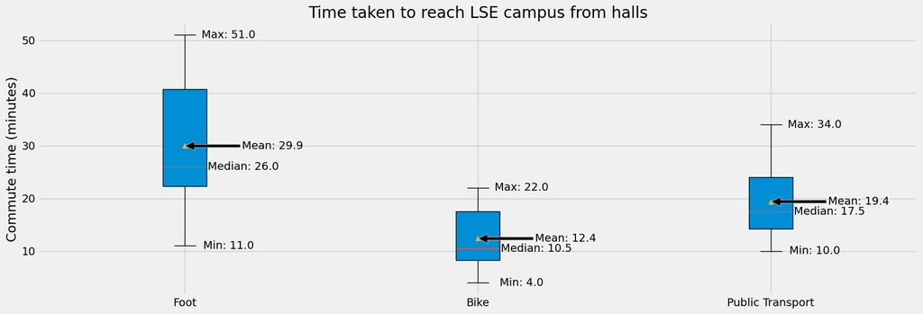

```python
import seaborn as sns
import matplotlib.pyplot as plt
from matplotlib.ticker import FuncFormatter

plt.style.use('fivethirtyeight')

fig, ax = plt.subplots(figsize=(18, 6))

# Annotate median, mean, max, and min on the boxplot
def annotate_values(ax, bp, position, label_x_offset=0.15, label_y_offset=-1):
    median = bp['medians'][0].get_ydata()[0]
    max_val = bp['whiskers'][1].get_ydata()[1]
    min_val = bp['whiskers'][0].get_ydata()[1]
    mean_val = bp['means'][0].get_ydata()[0]

    ax.annotate(f'Median: {median}',
                xy=(position, median),
                xytext=(position + label_x_offset + 0.05, median + label_y_offset),
                ha='center', va='bottom')

    ax.annotate(f'Mean: {round(mean_val, 1)}',
                xy=(position, mean_val),
                xytext=(position + label_x_offset + 0.15, mean_val + label_y_offset),
                arrowprops=dict(facecolor='black', shrink=0.005),
                ha='center', va='bottom')

    ax.annotate(f'Max: {max_val}',
                xy=(position, max_val),
                xytext=(position + label_x_offset, max_val + label_y_offset),
                ha='center', va='bottom')

    ax.annotate(f'Min: {min_val}',
                xy=(position, min_val),
                xytext=(position + label_x_offset, min_val + label_y_offset),
                ha='center', va='bottom')

# Helper function to remove x-axis labels
def remove_x_axis():
    ax.tick_params(axis='x',          # changes apply to the x-axis
                   which='both',      # both major and minor ticks are affected
                   bottom=False,      # ticks along the bottom edge are off
                   top=False,         # ticks along the top edge are off
                   labelbottom=False) # labels along the bottom edge are off

# Boxplot for commute times by foot
foot_data = accom_data['Time taken (Foot)'].dropna()
foot_bp = ax.boxplot(foot_data, positions=[1], patch_artist=True, whiskerprops=dict(color='black'), showmeans=True)
annotate_values(ax, foot_bp, position=1)

# Boxplot for commute times by bike
bike_data = accom_data['Time taken (Bike)'].dropna()
bike_bp = ax.boxplot(bike_data, positions=[2], patch_artist=True, whiskerprops=dict(color='black'), showmeans=True)
annotate_values(ax, bike_bp, position=2)

# Boxplot for commute times by public transport
public_transport_data = accom_data['Time taken (Public Transport)'].dropna()
public_transport_bp = ax.boxplot(public_transport_data, positions=[3], patch_artist=True, whiskerprops=dict(color='black'),
                                 showmeans=True)
annotate_values(ax, public_transport_bp, position=3)

# Set x-axis labels
ax.set_xticks([1, 2, 3])
ax.set_xticklabels(['Foot', 'Bike', 'Public Transport'])
ax.set_title('Time taken to reach LSE campus from halls')
ax.set_ylabel('Commute time (minutes)')

plt.show()
```

Overall and on average, the fastest way to travel to LSE from LSE accommodation halls is by bike. However, this does not mean it is the best way to travel. As students typically want to save money, they may prefer to walk (if they do not already own a bicycle) if the travel time by foot is under 20 minutes. For example, it is arguably more worth it for students staying in High Holborn Residence to walk to LSE since it only takes 11 minutes, even though it is faster to go by bike (4 minutes) or public transport (10 minutes). The time difference is not worth the money spent. Furthermore, especially for students that did not live in London before, travelling by bike can seem daunting or dangerous, especially in dark or rainy conditions.

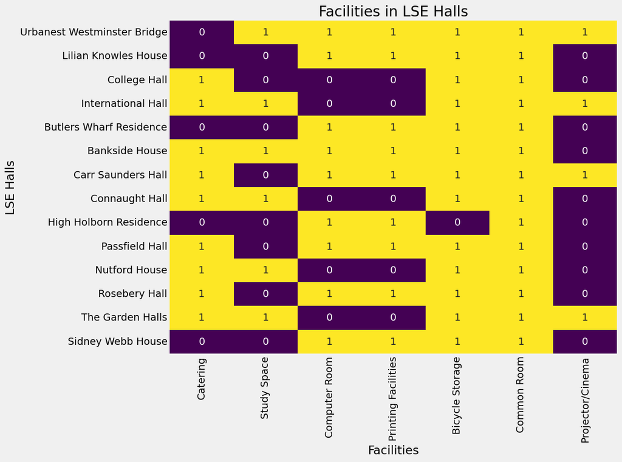

```python
## Extract the facilities columns, which start from 'Catering'
# Also, separate the hall names to use as y-axis labels
facilities_df = accom_data.loc[:, 'Catering':]
hall_names = accom_data['Name'].values

# Convert 'Y'/'N' to 1/0 for amenities
facilities = facilities_df.replace({'Y': 1, 'N': 0})

# Create the heatmap without the color bar
plt.figure(figsize=(10,8))
sns.heatmap(facilities, annot=True, cmap='viridis', cbar=False, yticklabels=hall_names)
plt.title('Facilities in LSE Halls')
plt.xlabel('Facilities')
plt.ylabel('LSE Halls')
plt.show()
```

Above is a visualisation of the facilities each accomodation hall has, indicated by the yellow boxes containing '1' (purple boxes containing '0' indicate that the hall does not have that facility). For example, it can be seen that every hall has a common room, and bicycle storage (except High Holborn Residence). Printing facilities are also most likely located in the Computer room, as halls either have both or neither.

### Comparison within halls

For comparison between halls, we analyse each room type and the corresponding price in terms of the following factors:

- Number of occupants: whether a room is occupied by only 1 student (i.e single rooms) or shared between multiple students (i.e non-single rooms).
- Type of bathroom: private (i.e ensuite; exclusive to the occupants of that room) or shared

Note: We do not differentiate between the number of students using a shared room/bathroom. The reasoning behind this analysis is that a student either values privacy (i.e only willing to stay in a single room) or is indifferent to privacy. Therefore, a student who is willing to share a room with 1 other student is also likely willing to share a room with 2 other students.

```python
single_bathroom = clean_room_df.groupby(['Room Type', 'Bathroom Type'])[['Price (£/week)']].count().sort_values(by='Price (£/week)',
                                                                                              ascending=False)
single_bathroom = single_bathroom.rename(columns={'Price (£/week)': 'Count'})
single_bathroom
```

| Room Type | Bathroom Type | Count |
| --- | --- | --- |
| Single | Shared bathroom | 19 |
| Single en suite | Private bathroom | 16 |
| Twin en suite | Private bathroom | 9 |
| Twin | Shared bathroom | 7 |
| Single studio | Private bathroom | 6 |
| Single with queen bed | Shared bathroom | 3 |
| Double en suite | Private bathroom | 2 |
| Double studio | Private bathroom | 2 |
| One-bed flat | Private bathroom | 2 |
| Triple | Shared bathroom | 2 |
| 3 bedroom flat | Shared bathroom | 1 |
| Double | Shared bathroom | 1 |
| Queen studio | Private bathroom | 1 |
| Single en suite (Townhouse) | Private bathroom | 1 |

Above shows all the types of room (and the corresponding type of bathroom) that a student can rent. The most common type of room offered in LSE accommodation halls is single rooms with a shared bathroom, followed by single ensuite rooms (with private bathrooms). Note that room types containg the words 'en suite' or 'studio' automatically imply a private bathroom. The room type 'One-bed flat' also naturally implies a private bathroom.

Also note that other than the 'single', 'twin', and 'triple' room types, the others do not explicitly state the number of occupants. This is to accomodate couples who wish to stay in the same room (with only one bed). However, this occurence is rare, so for the sake of this analysis, we will categorise these rooms under 'single' rooms.

```python
import plotly.express as px

# Define the single room keywords to search for
single_keywords = ['Single', 'One-bed', 'Studio', 'Double', '3 bedroom']

# Create a regular expression pattern to match any of the keywords
pattern_single = '|'.join(single_keywords)

# Apply filtering using str.contains() with the regex pattern
single_df = clean_room_df[clean_room_df['Room Type'].str.contains(pattern_single, flags=re.IGNORECASE, regex=True)]

# Define the non-single room keywords to search for
nonsingle_keywords = ['Triple', 'Twin']

# Create a regular expression pattern to match any of the keywords
nonsingle_pattern = '|'.join(nonsingle_keywords)

# Apply filtering using str.contains() with the regex pattern
nonsingle_df = clean_room_df[clean_room_df['Room Type'].str.contains(nonsingle_pattern, flags=re.IGNORECASE, regex=True)]
```

```python
import plotly.express as px

# Find the maximum price
single_price_max = single_df['Price (£/week)'].max()

# Find the room type and Hall Name at the maximum price
single_price_max_point = single_df.loc[single_df['Price (£/week)'].idxmax(), 'Room Type']
single_price_max_room = single_df['Hall Name'][single_df['Price (£/week)'].idxmax()]

# Find the minimum price
single_price_min = single_df['Price (£/week)'].min()

# Find the room type and Hall Name at the minimum price
single_price_min_point = single_df.loc[single_df['Price (£/week)'].idxmin(), 'Room Type']
single_price_min_room = single_df['Hall Name'][single_df['Price (£/week)'].idxmin()]

# Define color map with 'Queen studio' set to brown
color_map = {'Queen studio': 'brown'}

# Create violin plot for only the single rooms with modified color
fig = px.violin(single_df, x='Room Type', color='Room Type', y="Price (£/week)", points='all', hover_name='Hall Name',
                title='Price Distribution for Single rooms', color_discrete_map=color_map)

# Add annotation for the most expensive room
fig.add_annotation(x=single_price_max_point, y=single_price_max,
            text=f'Most expensive: £{single_price_max}/wk ({single_price_max_room})',
            showarrow=True, arrowhead=1, ax=20, ay=-10, xanchor='left')

# Add annotation for the cheapest room
fig.add_annotation(x=single_price_min_point, y=single_price_min,
            text=f'Cheapest: £{single_price_min}/wk ({single_price_min_room})',
            showarrow=True, arrowhead=1, ax=20, ay=10, xanchor='left')

fig.show()
```

[interactive chart not shown]

The above plot shows the price distribution for each type of single room. It may be worth de-selecting room types that have 2 or less points (i.e 'Double en suite', 'Double studio', 'Double', 'One-bed flat', 'Single en suite (Townhouse)', '3 bedroom flat', 'Queen studio') in order to more accurately see the price distribution of the remaining room types.

```python
# Find the maximum price
nonsingle_price_max = nonsingle_df['Price (£/week)'].max()

# Find the room type and Hall Name at the maximum price
nonsingle_price_max_point = nonsingle_df.loc[nonsingle_df['Price (£/week)'].idxmax(), 'Room Type']
nonsingle_price_max_room = nonsingle_df['Hall Name'][nonsingle_df['Price (£/week)'].idxmax()]

# Find the minimum price
nonsingle_price_min = nonsingle_df['Price (£/week)'].min()

# Find the room type and Hall Name at the minimum price
nonsingle_price_min_point = nonsingle_df.loc[nonsingle_df['Price (£/week)'].idxmin(), 'Room Type']
nonsingle_price_min_room = nonsingle_df['Hall Name'][nonsingle_df['Price (£/week)'].idxmin()]

# Create violin plot for only the non-single rooms
fig = px.violin(nonsingle_df, x='Room Type', color='Room Type', y="Price (£/week)", points = "all", hover_name = 'Hall Name',
                title = 'Price Distribution for Non-single rooms')

# Add annotation for the most expensive room
fig.add_annotation(x=nonsingle_price_max_point, y=nonsingle_price_max,
            text=f'Most expensive: £{nonsingle_price_max}/wk ({nonsingle_price_max_room})',
            showarrow=True, arrowhead=1, ax=20, ay=-10, xanchor = 'left')

# Add annotation for the cheapest room
fig.add_annotation(x=nonsingle_price_min_point, y=nonsingle_price_min,
            text=f'Cheapest: £{nonsingle_price_min}/wk ({nonsingle_price_min_room})',
            showarrow=True, arrowhead=1, ax=20, ay=10, xanchor = 'left')

fig.show()
```

[interactive chart not shown]

The above plot shows the price distribution for each type of non-single room. It can be seen that overall, twin en suite rooms are more expensive than twin rooms (which have shared bathrooms); the cheapest twin en suite room is almost the same price as the most expensive twin room. This price differential may be due to the perk of a private bathroom, but does room size play a part in this? Other factors outside of this analysis may also affect the price. We further examine this in Question 3.

However, this price differential is not as apparent in the price distribution for single rooms. The cheapest single en suite room is less than £5/wk more expensive than the cheapest single room. We also examine this difference in the price differentials of single vs non-single rooms in Question 3.

## Q2: Which accommodation option offers the best value for money?

To answer this question, we first define 'Value for Money'. Since each accommodation option differs in both quantitative (e.g room size) and qualitative (e.g private vs shared bathroom) aspects, it is difficult to rank each accommodation option while concurrently considering all the factors that we have identified earlier.

Therefore, we develop a points-based scoring system in which points are given/deducted as follows:

- Points are assigned to each amenity provided by the hall that the accommodation option is located in (i.e 10 points for each of the following: Catering, Study Space, Bicycle Storage, Common Room, Projector/Cinema; 5 points each for Computer Room and Printing Facilities).The sum of these points is the Amenities Score, which is added to the Total Score.**
- For each accommodation option, we take the fastest travel method (to LSE) among walking, bike, and public transport. The amount of time taken is the Commute score, which is deducted from the Total Score.
- We assume students value privacy (i.e prefer to be the only one occupying a room and using a bathroom). Therefore, 5 points are deducted each for non-single rooms and shared bathrooms.
- The Effective Room Size is calculated as the Room Size divided by the number of occupants. This number is added to the Total Score.

Each accommodation option starts at a Total Score of 0. After the above additions and deductions, we divide the Total Score by the Price (£/week) to get Value for Money.

** We allocate less points to Computer Room and Printing Facilities as these facilities are usually less vital for most students in an accomodation based on our street surveys.

```python
# Make copies of the original dataframes to preserve the original data
room_df_copy = clean_room_df.copy()
amenities_df_copy = accom_data.copy()
```

```python
# Assign points for amenities
amenities_points = {
    'Catering': 10,
    'Study Space': 10,
    'Computer Room': 5,
    'Printing Facilities': 5,
    'Bicycle Storage': 10,
    'Common Room': 10,
    'Projector/Cinema': 10
}

# Calculate amenities score for each hall
def calculate_amenities_score(row, amenities_points):
    score = 0
    for amenity, points in amenities_points.items():
        if row[amenity] == 'Y':
            score += points
    return score

amenities_df_copy['Amenities Score'] = amenities_df_copy.apply(calculate_amenities_score, axis=1, amenities_points=amenities_points)

# Calculate commute score for each hall
amenities_df_copy['Commute Score'] = amenities_df_copy[['Time taken (Foot)', 'Time taken (Bike)', 'Time taken (Public Transport)']].min(axis=1)

# Create a map of hall name to amenities and commute scores
hall_scores_map = amenities_df_copy.set_index('Name')[['Amenities Score', 'Commute Score']].to_dict('index')

# Add amenities and commute scores to the rooms dataframe
room_df_copy['Amenities Score'] = room_df_copy['Hall Name'].apply(lambda x: hall_scores_map[x]['Amenities Score'])
room_df_copy['Commute Score'] = room_df_copy['Hall Name'].apply(lambda x: hall_scores_map[x]['Commute Score'])

# Subtract points for shared bathroom (-5) or twin room (-5)
room_df_copy['Deductions'] = room_df_copy.apply(lambda row: (-5 if 'Shared' in row['Bathroom Type'] else 0) +
                                                            (-5 if any(keyword in row['Room Type'] for keyword in ['Twin', 'Triple']) else 0), axis=1)

# Convert 'Room Size (m²)' column to numeric type
room_df_copy['Room Size (m²)'] = pd.to_numeric(room_df_copy['Room Size (m²)'], errors='coerce')

# Calculate the effective room size for each of the room types based on the occupancy in each room
room_df_copy['Effective Room Size'] = room_df_copy.apply(lambda row:
    row['Room Size (m²)'] / 2 if any(keyword in row['Room Type'] for keyword in ['Twin', 'Double en suite']) else
    row['Room Size (m²)'] / 3 if any(keyword in row['Room Type'] for keyword in ['Triple', '3 bedroom flat']) else
    row['Room Size (m²)'], axis=1)

# Convert 'Price (£/week)' column to numeric type
room_df_copy['Price (£/week)'] = pd.to_numeric(room_df_copy['Price (£/week)'], errors='coerce')

# Calculate the total score and Value for Money
room_df_copy['Total Score'] = room_df_copy['Amenities Score'] - room_df_copy['Commute Score'] + room_df_copy['Deductions'] + room_df_copy['Effective Room Size'].round(2)
room_df_copy['Value for Money'] = room_df_copy['Total Score'] / room_df_copy['Price (£/week)']
room_df_copy['Effective Room Size'] = room_df_copy['Effective Room Size'].round(2)
room_df_copy['Value for Money'] = room_df_copy['Value for Money'].round(3)
room_df_copy
```

|  | Hall Name | Room Type | Bathroom Type | Room Size (m²) | Price (£/week) | Amenities Score | Commute Score | Deductions | Effective Room Size | Total Score | Value for Money |
| --- | --- | --- | --- | --- | --- | --- | --- | --- | --- | --- | --- |
| 1 | Urbanest Westminster Bridge | Single | Shared bathroom | 8.50 | 285.23 | 50 | 9.0 | -5 | 8.50 | 44.50 | 0.156 |
| 2 | Urbanest Westminster Bridge | Single | Shared bathroom | 8.50 | 310.76 | 50 | 9.0 | -5 | 8.50 | 44.50 | 0.143 |
| 3 | Urbanest Westminster Bridge | Single en suite | Private bathroom | 13.40 | 286.90 | 50 | 9.0 | 0 | 13.40 | 54.40 | 0.190 |
| 4 | Urbanest Westminster Bridge | Single en suite | Private bathroom | 13.40 | 346.90 | 50 | 9.0 | 0 | 13.40 | 54.40 | 0.157 |
| 5 | Urbanest Westminster Bridge | Twin en suite | Private bathroom | 25.30 | 227.09 | 50 | 9.0 | -5 | 12.65 | 48.65 | 0.214 |
| 6 | Urbanest Westminster Bridge | Twin en suite | Private bathroom | 25.30 | 240.22 | 50 | 9.0 | -5 | 12.65 | 48.65 | 0.203 |
| 7 | Urbanest Westminster Bridge | Single studio | Private bathroom | 22.10 | 420.03 | 50 | 9.0 | 0 | 22.10 | 63.10 | 0.150 |
| 8 | Urbanest Westminster Bridge | Single studio | Private bathroom | 22.10 | 458.32 | 50 | 9.0 | 0 | 22.10 | 63.10 | 0.138 |
| 9 | Lilian Knowles House | Single en suite | Private bathroom | 8.00 | 198.86 | 30 | 19.0 | 0 | 8.00 | 19.00 | 0.096 |
| 10 | Lilian Knowles House | Single en suite | Private bathroom | 14.00 | 242.35 | 30 | 19.0 | 0 | 14.00 | 25.00 | 0.103 |
| 11 | Lilian Knowles House | Single studio | Private bathroom | 12.00 | 263.59 | 30 | 19.0 | 0 | 12.00 | 23.00 | 0.087 |
| 12 | Lilian Knowles House | Single studio | Private bathroom | 22.00 | 303.15 | 30 | 19.0 | 0 | 22.00 | 33.00 | 0.109 |
| 13 | Lilian Knowles House | One-bed flat | Private bathroom | 21.00 | 303.15 | 30 | 19.0 | 0 | 21.00 | 32.00 | 0.106 |
| 14 | Lilian Knowles House | One-bed flat | Private bathroom | 27.00 | 336.43 | 30 | 19.0 | 0 | 27.00 | 38.00 | 0.113 |
| 15 | College Hall | Single | Shared bathroom | 12.00 | 289.73 | 30 | 8.0 | -5 | 12.00 | 29.00 | 0.100 |
| 16 | College Hall | Single en suite | Private bathroom | 14.00 | 332.43 | 30 | 8.0 | 0 | 14.00 | 36.00 | 0.108 |
| 17 | College Hall | Double en suite | Private bathroom | 17.00 | 392.63 | 30 | 8.0 | 0 | 8.50 | 30.50 | 0.078 |
| 18 | International Hall | Single | Shared bathroom | 8.95 | 266.28 | 50 | 8.0 | -5 | 8.95 | 45.95 | 0.173 |
| 19 | International Hall | Single studio | Private bathroom | 16.40 | 294.98 | 50 | 8.0 | 0 | 16.40 | 58.40 | 0.198 |
| 20 | International Hall | Single studio | Private bathroom | 18.90 | 301.28 | 50 | 8.0 | 0 | 18.90 | 60.90 | 0.202 |
| 21 | International Hall | Double studio | Private bathroom | 18.90 | 321.93 | 50 | 8.0 | 0 | 18.90 | 60.90 | 0.189 |
| 22 | Butlers Wharf Residence | Single | Shared bathroom | 10.00 | 194.60 | 30 | 22.0 | -5 | 10.00 | 13.00 | 0.067 |
| 23 | Butlers Wharf Residence | Single | Shared bathroom | 10.00 | 267.40 | 30 | 22.0 | -5 | 10.00 | 13.00 | 0.049 |
| 24 | Butlers Wharf Residence | Twin | Shared bathroom | 14.00 | 127.40 | 30 | 22.0 | -10 | 7.00 | 5.00 | 0.039 |
| 25 | Butlers Wharf Residence | Twin | Shared bathroom | 14.00 | 153.65 | 30 | 22.0 | -10 | 7.00 | 5.00 | 0.033 |
| 26 | Butlers Wharf Residence | Double | Shared bathroom | 15.00 | 278.95 | 30 | 22.0 | -5 | 15.00 | 18.00 | 0.065 |
| 27 | Bankside House | Single | Shared bathroom | 12.50 | 259.70 | 50 | 13.0 | -5 | 12.50 | 44.50 | 0.171 |
| 28 | Bankside House | Single en suite | Private bathroom | 15.66 | 277.20 | 50 | 13.0 | 0 | 15.66 | 52.66 | 0.190 |
| 29 | Bankside House | Single en suite | Private bathroom | 17.11 | 297.15 | 50 | 13.0 | 0 | 17.11 | 54.11 | 0.182 |
| 30 | Bankside House | Twin en suite | Private bathroom | 23.55 | 167.65 | 50 | 13.0 | -5 | 11.78 | 43.78 | 0.261 |
| 31 | Bankside House | Twin en suite | Private bathroom | 25.32 | 186.20 | 50 | 13.0 | -5 | 12.66 | 44.66 | 0.240 |
| 32 | Carr Saunders Hall | Single | Shared bathroom | 9.00 | 257.25 | 50 | 11.0 | -5 | 9.00 | 43.00 | 0.167 |
| 33 | Carr Saunders Hall | Single with queen bed | Shared bathroom | 9.00 | 259.35 | 50 | 11.0 | -5 | 9.00 | 43.00 | 0.166 |
| 34 | Carr Saunders Hall | Twin | Shared bathroom | 20.00 | 173.25 | 50 | 11.0 | -10 | 10.00 | 39.00 | 0.225 |
| 35 | Carr Saunders Hall | Twin en suite | Private bathroom | 20.00 | 185.50 | 50 | 11.0 | -5 | 10.00 | 44.00 | 0.237 |
| 36 | Connaught Hall | Single | Shared bathroom | 9.00 | 273.63 | 40 | 8.0 | -5 | 9.00 | 36.00 | 0.132 |
| 37 | High Holborn Residence | Single | Shared bathroom | 9.50 | 317.80 | 20 | 4.0 | -5 | 9.50 | 20.50 | 0.065 |
| 38 | High Holborn Residence | Single | Shared bathroom | 12.60 | 317.80 | 20 | 4.0 | -5 | 12.60 | 23.60 | 0.074 |
| 39 | High Holborn Residence | Single with queen bed | Shared bathroom | 9.50 | 333.90 | 20 | 4.0 | -5 | 9.50 | 20.50 | 0.061 |
| 40 | High Holborn Residence | Single with queen bed | Shared bathroom | 12.60 | 333.90 | 20 | 4.0 | -5 | 12.60 | 23.60 | 0.071 |
| 41 | High Holborn Residence | Single en suite | Private bathroom | 9.50 | 333.20 | 20 | 4.0 | 0 | 9.50 | 25.50 | 0.077 |
| 42 | High Holborn Residence | Single en suite | Private bathroom | 12.60 | 333.20 | 20 | 4.0 | 0 | 12.60 | 28.60 | 0.086 |
| 43 | High Holborn Residence | Twin en suite | Private bathroom | 16.00 | 184.45 | 20 | 4.0 | -5 | 8.00 | 19.00 | 0.103 |
| 44 | Passfield Hall | Single | Shared bathroom | 6.20 | 231.00 | 40 | 10.0 | -5 | 6.20 | 31.20 | 0.135 |
| 45 | Passfield Hall | Single | Shared bathroom | 15.30 | 274.75 | 40 | 10.0 | -5 | 15.30 | 40.30 | 0.147 |
| 46 | Passfield Hall | Single en suite | Private bathroom | 9.00 | 287.35 | 40 | 10.0 | 0 | 9.00 | 39.00 | 0.136 |
| 47 | Passfield Hall | Twin | Shared bathroom | 17.60 | 158.90 | 40 | 10.0 | -10 | 8.80 | 28.80 | 0.181 |
| 48 | Passfield Hall | Twin | Shared bathroom | 23.00 | 166.60 | 40 | 10.0 | -10 | 11.50 | 31.50 | 0.189 |
| 49 | Passfield Hall | Twin en suite | Private bathroom | 17.60 | 182.70 | 40 | 10.0 | -5 | 8.80 | 33.80 | 0.185 |
| 50 | Passfield Hall | Twin en suite | Private bathroom | 23.00 | 182.70 | 40 | 10.0 | -5 | 11.50 | 36.50 | 0.200 |
| 51 | Passfield Hall | Triple | Shared bathroom | 31.00 | 129.85 | 40 | 10.0 | -10 | 10.33 | 30.33 | 0.234 |
| 52 | Passfield Hall | Triple | Shared bathroom | 31.00 | 140.70 | 40 | 10.0 | -10 | 10.33 | 30.33 | 0.216 |
| 53 | Nutford House | Single | Shared bathroom | 6.40 | 236.88 | 40 | 21.0 | -5 | 6.40 | 20.40 | 0.086 |
| 54 | Nutford House | Single | Shared bathroom | 6.40 | 263.48 | 40 | 21.0 | -5 | 6.40 | 20.40 | 0.077 |
| 55 | Rosebery Hall | Single | Shared bathroom | 10.50 | 247.80 | 40 | 12.0 | -5 | 10.50 | 33.50 | 0.135 |
| 56 | Rosebery Hall | Single | Shared bathroom | 11.00 | 263.90 | 40 | 12.0 | -5 | 11.00 | 34.00 | 0.129 |
| 57 | Rosebery Hall | Twin | Shared bathroom | 15.50 | 168.70 | 40 | 12.0 | -10 | 7.75 | 25.75 | 0.153 |
| 58 | Rosebery Hall | Twin | Shared bathroom | 17.50 | 168.70 | 40 | 12.0 | -10 | 8.75 | 26.75 | 0.159 |
| 59 | Rosebery Hall | Twin en suite | Private bathroom | 17.50 | 185.50 | 40 | 12.0 | -5 | 8.75 | 31.75 | 0.171 |
| 60 | The Garden Halls | Single | Shared bathroom | 10.00 | 269.64 | 50 | 9.0 | -5 | 10.00 | 46.00 | 0.171 |
| 61 | The Garden Halls | Single | Shared bathroom | 10.00 | 288.75 | 50 | 9.0 | -5 | 10.00 | 46.00 | 0.159 |
| 62 | The Garden Halls | Single en suite | Private bathroom | 12.60 | 358.61 | 50 | 9.0 | 0 | 12.60 | 53.60 | 0.149 |
| 63 | The Garden Halls | Single en suite | Private bathroom | 15.50 | 358.61 | 50 | 9.0 | 0 | 15.50 | 56.50 | 0.158 |
| 64 | The Garden Halls | Single en suite | Private bathroom | 13.00 | 371.70 | 50 | 9.0 | 0 | 13.00 | 54.00 | 0.145 |
| 65 | The Garden Halls | Single en suite | Private bathroom | 15.00 | 374.08 | 50 | 9.0 | 0 | 15.00 | 56.00 | 0.150 |
| 66 | The Garden Halls | Single en suite (Townhouse) | Private bathroom | 9.50 | 314.16 | 50 | 9.0 | 0 | 9.50 | 50.50 | 0.161 |
| 67 | Sidney Webb House | Single en suite | Private bathroom | 10.20 | 221.90 | 30 | 19.0 | 0 | 10.20 | 21.20 | 0.096 |
| 68 | Sidney Webb House | Single en suite | Private bathroom | 12.10 | 244.65 | 30 | 19.0 | 0 | 12.10 | 23.10 | 0.094 |
| 69 | Sidney Webb House | 3 bedroom flat | Shared bathroom | 12.10 | 277.90 | 30 | 19.0 | -5 | 4.03 | 10.03 | 0.036 |
| 70 | Sidney Webb House | Double en suite | Private bathroom | 20.10 | 290.85 | 30 | 19.0 | 0 | 10.05 | 21.05 | 0.072 |
| 71 | Sidney Webb House | Double studio | Private bathroom | 21.30 | 336.70 | 30 | 19.0 | 0 | 21.30 | 32.30 | 0.096 |
| 72 | Sidney Webb House | Queen studio | Private bathroom | 22.50 | 331.45 | 30 | 19.0 | 0 | 22.50 | 33.50 | 0.101 |

We have created a DataFrame where we can see the points system clearly. Each accommodation option has a Total Score, which when divided by Price (£/week), results in its Value for Money.

Now, we can rank the accommodation options by Value for Money. For completeness, we also rank them by Total Score.

- For the rankings to be meaningful, the student must first be eligible to stay in the hall. Therefore, we split the rankings for Undergraduate and Postgraduate students.

**Ranking by Value for Money**

```python
## For Undergraduate Eligibility
# Split the DataFrame into undergraduate single and non-single rooms and sort by value for money
undergraduate_single_rooms = room_df_copy[(room_df_copy['Hall Name'].isin(amenities_df_copy[amenities_df_copy['Eligibility'].isin(['UG priority', 'UG', 'UG/PG'])]['Name'])) & (room_df_copy['Room Type'].str.contains('|'.join(single_keywords)))].sort_values('Value for Money', ascending=False).reset_index(drop=True)
undergraduate_nonsingle_rooms = room_df_copy[(room_df_copy['Hall Name'].isin(amenities_df_copy[amenities_df_copy['Eligibility'].isin(['UG priority', 'UG', 'UG/PG'])]['Name'])) & (~room_df_copy['Room Type'].str.contains('|'.join(single_keywords)))].sort_values('Value for Money', ascending=False).reset_index(drop=True)
undergraduate_rooms = room_df_copy[(room_df_copy['Hall Name'].isin(amenities_df_copy[amenities_df_copy['Eligibility'].isin(['UG priority', 'UG', 'UG/PG'])]['Name']))].sort_values('Value for Money', ascending=False).reset_index(drop=True)

# Print out the rankings for undergraduate rooms
print("Top 5 Undergraduate Single Rooms Ranking by Value for Money:")
display(undergraduate_single_rooms[['Hall Name', 'Room Type', 'Bathroom Type', 'Price (£/week)', 'Total Score', 'Value for Money']].head())

print("\nTop 5 Undergraduate Non-Single Rooms Ranking by Value for Money:")
display(undergraduate_nonsingle_rooms[['Hall Name', 'Room Type', 'Bathroom Type', 'Price (£/week)', 'Total Score', 'Value for Money']].head())

print("\nTop 5 Undergraduate Overall Ranking by Value for Money:")
display(undergraduate_rooms[['Hall Name', 'Room Type', 'Bathroom Type', 'Price (£/week)', 'Total Score', 'Value for Money']].head())

## For Postgraduate Eligibility
# Split the DataFrame into postgraduate single and non-single rooms and sort by value for money
postgraduate_single_rooms = room_df_copy[(room_df_copy['Hall Name'].isin(amenities_df_copy[amenities_df_copy['Eligibility'].isin(['PG', 'UG/PG'])]['Name'])) & (room_df_copy['Room Type'].str.contains('|'.join(single_keywords)))].sort_values('Value for Money', ascending=False).reset_index(drop=True)
postgraduate_nonsingle_rooms = room_df_copy[(room_df_copy['Hall Name'].isin(amenities_df_copy[amenities_df_copy['Eligibility'].isin(['PG', 'UG/PG'])]['Name'])) & (~room_df_copy['Room Type'].str.contains('|'.join(single_keywords)))].sort_values('Value for Money', ascending=False).reset_index(drop=True)
postgraduate_rooms = room_df_copy[(room_df_copy['Hall Name'].isin(amenities_df_copy[amenities_df_copy['Eligibility'].isin(['PG', 'UG/PG'])]['Name']))].sort_values('Value for Money', ascending=False).reset_index(drop=True)

# Print out the rankings for postgraduate rooms
print("\nTop 5 Postgraduate Single Rooms Ranking by Value for Money:")
display(postgraduate_single_rooms[['Hall Name', 'Room Type', 'Bathroom Type', 'Price (£/week)', 'Total Score', 'Value for Money']].head())

print("\nTop 5 Postgraduate Non-Single Rooms Ranking by Value for Money:")
display(postgraduate_nonsingle_rooms[['Hall Name', 'Room Type', 'Bathroom Type', 'Price (£/week)', 'Total Score', 'Value for Money']].head())

print("\nTop 5 Postgraduate Overall Ranking by Value for Money:")
display(postgraduate_rooms[['Hall Name', 'Room Type', 'Bathroom Type', 'Price (£/week)', 'Total Score', 'Value for Money']].head())
```

```
Top 5 Undergraduate Single Rooms Ranking by Value for Money:
```

|  | Hall Name | Room Type | Bathroom Type | Price (£/week) | Total Score | Value for Money |
| --- | --- | --- | --- | --- | --- | --- |
| 0 | International Hall | Single studio | Private bathroom | 301.28 | 60.90 | 0.202 |
| 1 | International Hall | Single studio | Private bathroom | 294.98 | 58.40 | 0.198 |
| 2 | Urbanest Westminster Bridge | Single en suite | Private bathroom | 286.90 | 54.40 | 0.190 |
| 3 | Bankside House | Single en suite | Private bathroom | 277.20 | 52.66 | 0.190 |
| 4 | International Hall | Double studio | Private bathroom | 321.93 | 60.90 | 0.189 |

```
Top 5 Undergraduate Non-Single Rooms Ranking by Value for Money:
```

|  | Hall Name | Room Type | Bathroom Type | Price (£/week) | Total Score | Value for Money |
| --- | --- | --- | --- | --- | --- | --- |
| 0 | Bankside House | Twin en suite | Private bathroom | 167.65 | 43.78 | 0.261 |
| 1 | Bankside House | Twin en suite | Private bathroom | 186.20 | 44.66 | 0.240 |
| 2 | Carr Saunders Hall | Twin en suite | Private bathroom | 185.50 | 44.00 | 0.237 |
| 3 | Passfield Hall | Triple | Shared bathroom | 129.85 | 30.33 | 0.234 |
| 4 | Carr Saunders Hall | Twin | Shared bathroom | 173.25 | 39.00 | 0.225 |

```
Top 5 Undergraduate Overall Ranking by Value for Money:
```

|  | Hall Name | Room Type | Bathroom Type | Price (£/week) | Total Score | Value for Money |
| --- | --- | --- | --- | --- | --- | --- |
| 0 | Bankside House | Twin en suite | Private bathroom | 167.65 | 43.78 | 0.261 |
| 1 | Bankside House | Twin en suite | Private bathroom | 186.20 | 44.66 | 0.240 |
| 2 | Carr Saunders Hall | Twin en suite | Private bathroom | 185.50 | 44.00 | 0.237 |
| 3 | Passfield Hall | Triple | Shared bathroom | 129.85 | 30.33 | 0.234 |
| 4 | Carr Saunders Hall | Twin | Shared bathroom | 173.25 | 39.00 | 0.225 |

```
Top 5 Postgraduate Single Rooms Ranking by Value for Money:
```

|  | Hall Name | Room Type | Bathroom Type | Price (£/week) | Total Score | Value for Money |
| --- | --- | --- | --- | --- | --- | --- |
| 0 | Urbanest Westminster Bridge | Single en suite | Private bathroom | 286.90 | 54.4 | 0.190 |
| 1 | Urbanest Westminster Bridge | Single en suite | Private bathroom | 346.90 | 54.4 | 0.157 |
| 2 | Urbanest Westminster Bridge | Single | Shared bathroom | 285.23 | 44.5 | 0.156 |
| 3 | Urbanest Westminster Bridge | Single studio | Private bathroom | 420.03 | 63.1 | 0.150 |
| 4 | Urbanest Westminster Bridge | Single | Shared bathroom | 310.76 | 44.5 | 0.143 |

```
Top 5 Postgraduate Non-Single Rooms Ranking by Value for Money:
```

|  | Hall Name | Room Type | Bathroom Type | Price (£/week) | Total Score | Value for Money |
| --- | --- | --- | --- | --- | --- | --- |
| 0 | Urbanest Westminster Bridge | Twin en suite | Private bathroom | 227.09 | 48.65 | 0.214 |
| 1 | Urbanest Westminster Bridge | Twin en suite | Private bathroom | 240.22 | 48.65 | 0.203 |
| 2 | High Holborn Residence | Twin en suite | Private bathroom | 184.45 | 19.00 | 0.103 |
| 3 | Sidney Webb House | Queen studio | Private bathroom | 331.45 | 33.50 | 0.101 |
| 4 | Butlers Wharf Residence | Twin | Shared bathroom | 127.40 | 5.00 | 0.039 |

```
Top 5 Postgraduate Overall Ranking by Value for Money:
```

|  | Hall Name | Room Type | Bathroom Type | Price (£/week) | Total Score | Value for Money |
| --- | --- | --- | --- | --- | --- | --- |
| 0 | Urbanest Westminster Bridge | Twin en suite | Private bathroom | 227.09 | 48.65 | 0.214 |
| 1 | Urbanest Westminster Bridge | Twin en suite | Private bathroom | 240.22 | 48.65 | 0.203 |
| 2 | Urbanest Westminster Bridge | Single en suite | Private bathroom | 286.90 | 54.40 | 0.190 |
| 3 | Urbanest Westminster Bridge | Single en suite | Private bathroom | 346.90 | 54.40 | 0.157 |
| 4 | Urbanest Westminster Bridge | Single | Shared bathroom | 285.23 | 44.50 | 0.156 |

The above rankings show the best accommodation options in terms of Value for Money for Undergraduate students, and for Postgraduate students.

Undergraduate students:

- For students who prefer not to share a room, the best option would be a Single studio in International Hall at £301.28/wk.
- Note that the Top 5 Undergraduate Overall Ranking is the same as the Top 5 Undergraduate Non-Single Rooms Ranking. Therefore, for students who either prefer or are indifferent to sharing a room, the best option would be a Twin en suite in Bankside House at £167.65/wk.

Postgraduate students:

- For students who prefer not to share a room, the best option would be a Single en suite room in Urbanest Westminster Bridge at £286.90/wk. In fact, the best 5 options are all located in Urbanest Westminster Bridge.
- For students who either prefer or are indifferent to sharing a room, the best option would be a Twin en suite in Urbanest Westminster Bridge at £227.09/wk.

It appears that sharing a room often corresponds to a lower Price (£/week), which results in a higher Value for Money. Students may want to take this into consideration if they are willing to compromise on their privacy to save money.

**Ranking by Total Score**

```python
# For Undergraduate Eligibility
# Split the DataFrame into undergraduate single and non-single rooms and sort by total score
undergraduate_single_rooms = undergraduate_single_rooms.sort_values('Total Score', ascending=False).reset_index(drop=True)
undergraduate_nonsingle_rooms = undergraduate_nonsingle_rooms.sort_values('Total Score', ascending=False).reset_index(drop=True)
undergraduate_rooms = undergraduate_rooms.sort_values('Total Score', ascending=False).reset_index(drop=True)

# Print out the rankings for undergraduate rooms
print("Top 5 Undergraduate Single Rooms Ranking by Total Score:")
display(undergraduate_single_rooms[['Hall Name', 'Room Type', 'Bathroom Type', 'Price (£/week)', 'Total Score']].head())

print("\nTop 5 Undergraduate Non-Single Rooms Ranking by Total Score:")
display(undergraduate_nonsingle_rooms[['Hall Name', 'Room Type', 'Bathroom Type', 'Price (£/week)', 'Total Score']].head())

print("\nTop 5 Undergraduate Overall Ranking by Total Score:")
display(undergraduate_rooms[['Hall Name', 'Room Type', 'Bathroom Type', 'Price (£/week)', 'Total Score']].head())

# For Postgraduate Eligibility
# Split the DataFrame into postgraduate single and non-single rooms and sort by total score
postgraduate_single_rooms = postgraduate_single_rooms.sort_values('Total Score', ascending=False).reset_index(drop=True)
postgraduate_nonsingle_rooms = postgraduate_nonsingle_rooms.sort_values('Total Score', ascending=False).reset_index(drop=True)
postgraduate_rooms = postgraduate_rooms.sort_values('Total Score', ascending=False).reset_index(drop=True)

# Print out the rankings for postgraduate rooms
print("\nTop 5 Postgraduate Single Rooms Ranking by Total Score:")
display(postgraduate_single_rooms[['Hall Name', 'Room Type', 'Bathroom Type', 'Price (£/week)', 'Total Score']].head())

print("\nTop 5 Postgraduate Non-Single Rooms Ranking by Total Score:")
display(postgraduate_nonsingle_rooms[['Hall Name', 'Room Type', 'Bathroom Type', 'Price (£/week)', 'Total Score']].head())

print("\nTop 5 Postgraduate Overall Ranking by Total Score:")
display(postgraduate_rooms[['Hall Name', 'Room Type', 'Bathroom Type', 'Price (£/week)', 'Total Score']].head())
```

```
Top 5 Undergraduate Single Rooms Ranking by Total Score:
```

|  | Hall Name | Room Type | Bathroom Type | Price (£/week) | Total Score |
| --- | --- | --- | --- | --- | --- |
| 0 | Urbanest Westminster Bridge | Single studio | Private bathroom | 458.32 | 63.1 |
| 1 | Urbanest Westminster Bridge | Single studio | Private bathroom | 420.03 | 63.1 |
| 2 | International Hall | Double studio | Private bathroom | 321.93 | 60.9 |
| 3 | International Hall | Single studio | Private bathroom | 301.28 | 60.9 |
| 4 | International Hall | Single studio | Private bathroom | 294.98 | 58.4 |

```
Top 5 Undergraduate Non-Single Rooms Ranking by Total Score:
```

|  | Hall Name | Room Type | Bathroom Type | Price (£/week) | Total Score |
| --- | --- | --- | --- | --- | --- |
| 0 | Urbanest Westminster Bridge | Twin en suite | Private bathroom | 227.09 | 48.65 |
| 1 | Urbanest Westminster Bridge | Twin en suite | Private bathroom | 240.22 | 48.65 |
| 2 | Bankside House | Twin en suite | Private bathroom | 186.20 | 44.66 |
| 3 | Carr Saunders Hall | Twin en suite | Private bathroom | 185.50 | 44.00 |
| 4 | Bankside House | Twin en suite | Private bathroom | 167.65 | 43.78 |

```
Top 5 Undergraduate Overall Ranking by Total Score:
```

|  | Hall Name | Room Type | Bathroom Type | Price (£/week) | Total Score |
| --- | --- | --- | --- | --- | --- |
| 0 | Urbanest Westminster Bridge | Single studio | Private bathroom | 458.32 | 63.1 |
| 1 | Urbanest Westminster Bridge | Single studio | Private bathroom | 420.03 | 63.1 |
| 2 | International Hall | Single studio | Private bathroom | 301.28 | 60.9 |
| 3 | International Hall | Double studio | Private bathroom | 321.93 | 60.9 |
| 4 | International Hall | Single studio | Private bathroom | 294.98 | 58.4 |

```
Top 5 Postgraduate Single Rooms Ranking by Total Score:
```

|  | Hall Name | Room Type | Bathroom Type | Price (£/week) | Total Score |
| --- | --- | --- | --- | --- | --- |
| 0 | Urbanest Westminster Bridge | Single studio | Private bathroom | 420.03 | 63.1 |
| 1 | Urbanest Westminster Bridge | Single studio | Private bathroom | 458.32 | 63.1 |
| 2 | Urbanest Westminster Bridge | Single en suite | Private bathroom | 286.90 | 54.4 |
| 3 | Urbanest Westminster Bridge | Single en suite | Private bathroom | 346.90 | 54.4 |
| 4 | Urbanest Westminster Bridge | Single | Shared bathroom | 285.23 | 44.5 |

```
Top 5 Postgraduate Non-Single Rooms Ranking by Total Score:
```

|  | Hall Name | Room Type | Bathroom Type | Price (£/week) | Total Score |
| --- | --- | --- | --- | --- | --- |
| 0 | Urbanest Westminster Bridge | Twin en suite | Private bathroom | 227.09 | 48.65 |
| 1 | Urbanest Westminster Bridge | Twin en suite | Private bathroom | 240.22 | 48.65 |
| 2 | Sidney Webb House | Queen studio | Private bathroom | 331.45 | 33.50 |
| 3 | High Holborn Residence | Twin en suite | Private bathroom | 184.45 | 19.00 |
| 4 | Butlers Wharf Residence | Twin | Shared bathroom | 127.40 | 5.00 |

```
Top 5 Postgraduate Overall Ranking by Total Score:
```

|  | Hall Name | Room Type | Bathroom Type | Price (£/week) | Total Score |
| --- | --- | --- | --- | --- | --- |
| 0 | Urbanest Westminster Bridge | Single studio | Private bathroom | 420.03 | 63.10 |
| 1 | Urbanest Westminster Bridge | Single studio | Private bathroom | 458.32 | 63.10 |
| 2 | Urbanest Westminster Bridge | Single en suite | Private bathroom | 286.90 | 54.40 |
| 3 | Urbanest Westminster Bridge | Single en suite | Private bathroom | 346.90 | 54.40 |
| 4 | Urbanest Westminster Bridge | Twin en suite | Private bathroom | 227.09 | 48.65 |

The above rankings show the best accommodation options in terms of Total Score for Undergraduate students, and for Postgraduate students.

Undergraduate students:

- Note that the Top 5 Undergraduate Overall Ranking is the same as the Top 5 Undergraduate Single Rooms Ranking. This means that regardless of whether a student prefers to share a room or not, the best option would be to stay in a single room. Specifically, the top option by Total Score is a single studio at Urbanest Westminster Bridge at £420.03/wk or £458.32/wk.

Postgraduate students:

- Except for the 5th ranking, it is the same case as for Undergraduate students. The top option is also the same.

When comparing the ranking by Value for Money and ranking by Total Score, it can be seen that the 'best' options differ vastly in terms of price. The best option in terms of Total Score is almost twice the price of most of the best options in terms of Value for Money. Although the best options in terms of Total Score overall have higher scores than the best options in terms of Value for Money, this is offset by the large difference in price- hence more expensive options do not necessarily mean they are better. The extent to which score is correlated with price is analysed in Question 3.

## Q3: Do any particular factors play a significant role in determining the price of an accommodation option?

**Effect of factors on price**

The price of an accommodation option is determined by many factors, which can stem from differences in the hall that the accommodation option is located in, or from differences between the options. We have identified these factors, so now we analyse the extent to which these factors impact the price (i.e how important a factor is in determining the price).

```python
corr_matrix = room_df_copy.corr().round(4)
corr_matrix
```

|  | Room Size (m²) | Price (£/week) | Amenities Score | Commute Score | Deductions | Effective Room Size | Total Score | Value for Money |
| --- | --- | --- | --- | --- | --- | --- | --- | --- |
| Room Size (m²) | 1.0000 | -0.1791 | 0.1338 | 0.0125 | -0.0973 | 0.5128 | 0.2300 | 0.4843 |
| Price (£/week) | -0.1791 | 1.0000 | 0.0129 | -0.2742 | 0.7306 | 0.5259 | 0.4490 | -0.2693 |
| Amenities Score | 0.1338 | 0.0129 | 1.0000 | -0.1794 | -0.0050 | 0.0786 | 0.8058 | 0.7821 |
| Commute Score | 0.0125 | -0.2742 | -0.1794 | 1.0000 | 0.0094 | 0.0587 | -0.4768 | -0.3789 |
| Deductions | -0.0973 | 0.7306 | -0.0050 | 0.0094 | 1.0000 | 0.5535 | 0.4038 | -0.1499 |
| Effective Room Size | 0.5128 | 0.5259 | 0.0786 | 0.0587 | 0.5535 | 1.0000 | 0.4809 | 0.1196 |
| Total Score | 0.2300 | 0.4490 | 0.8058 | -0.4768 | 0.4038 | 0.4809 | 1.0000 | 0.7021 |
| Value for Money | 0.4843 | -0.2693 | 0.7821 | -0.3789 | -0.1499 | 0.1196 | 0.7021 | 1.0000 |

For correlations with Price (£/week), Deductions, and Effective Room Size have the largest correlations (0.7306 and 0.5259 respectively). As Deductions are negative points given for a shared room or bathroom, these positive correlations imply that a higher relative price could be mainly attributed to the room and its bathroom being private, as well as a larger room.

This aligns with our earlier observation in Question 1, where we observed that en suite rooms tend to be more expensive than rooms with shared bathrooms, and studio rooms tend to be even more expensive.

```python
px.scatter(room_df_copy.sort_values(by = 'Effective Room Size', ascending = True), x='Effective Room Size', y='Price (£/week)',
           hover_name = 'Hall Name', color='Room Type', height = 600, title="Correlation between Room Size and Price")
```

[interactive chart not shown]

As seen in the scatterplot above, these is a loose positive relationship between the room size (Effective Room Size was used as it is essentially the portion of the shared room that 1 sharer pays for) and the price.

**Magnitude of effect**

We also analyse the difference in the magnitude of the effect (of factors that determine price) between single and non-single rooms, for options that are available to Undergraduate students and options that are available to Postgraduate students.

```python
print('Correlation with Price (£/week):')
print(corr_matrix.loc['Price (£/week)'].round(2))
```

```
Correlation with Price (£/week):
Room Size (m²)        -0.18
Price (£/week)         1.00
Amenities Score        0.01
Commute Score         -0.27
Deductions             0.73
Effective Room Size    0.53
Total Score            0.45
Value for Money       -0.27
Name: Price (£/week), dtype: float64
```

As Total Score consists of Amenities Score, Commute Score, Deductions, and Effective Room Size, the correlation between Total Score and Price (£/week) is a good indicator of how important these factors (i.e amenities, travel time, type of room/bathroom, room size) are in determining the price of an accommodation option. The overall correlation is 0.45, but does this differ for rooms available to Undergraduate students and rooms available to Postgraduate students? Furthermore, within these 2 eligibility groups, is there a difference in the correlation for single vs non-single rooms? We analyse this in the form of a heatmap below.

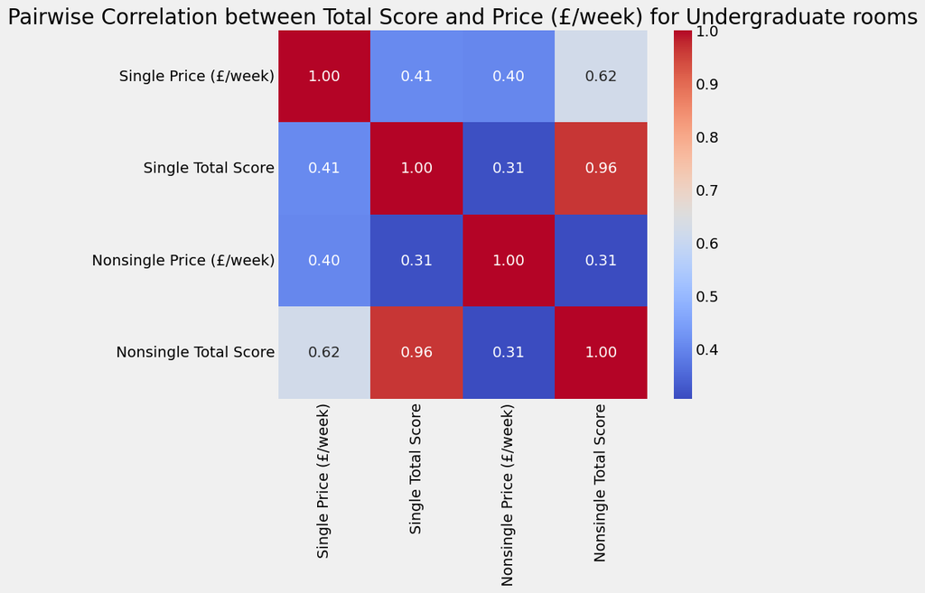

```python
## For undergradute rooms
# Select the columns of interest from each DataFrame
single_data_undergrad = undergraduate_single_rooms[["Price (£/week)", "Total Score"]]
single_data_undergrad.columns = ["Single Price (£/week)", "Single Total Score"]

nonsingle_data_undergrad = undergraduate_nonsingle_rooms[["Price (£/week)", "Total Score"]]
nonsingle_data_undergrad.columns = ["Nonsingle Price (£/week)", "Nonsingle Total Score"]

# Concatenate the two DataFrames along the columns axis
combined_data_undergrad = pd.concat([single_data_undergrad, nonsingle_data_undergrad], axis=1)

# Calculate correlation matrix
correlation_undergrad = combined_data_undergrad.corr()

# Plot the correlation matrix
plt.figure(figsize=(8, 6))
sns.heatmap(correlation_undergrad, annot=True, cmap='coolwarm', fmt=".2f", square=True)
plt.title('Pairwise Correlation between Total Score and Price (£/week) for Undergraduate rooms')
plt.show()
```

For options available to Undergrdauate students, the correlation between Total Score and Price (£/week) for single rooms is slightly higher than the correlation for non-single rooms (0.41 and 0.31 respectively). This means the factors captured in Total Score have a larger effect on the price for single rooms compared to non-single rooms.

However, further analysis is needed to judge whether this difference in effect is significant. It is also possible that there are other factors that affect the price, that were not or could not be taken into account in this analysis. For example, the specific location of the room within the hall may have an effect on the price of the room, and the magnitude of this effect may be different for single and non-single rooms.

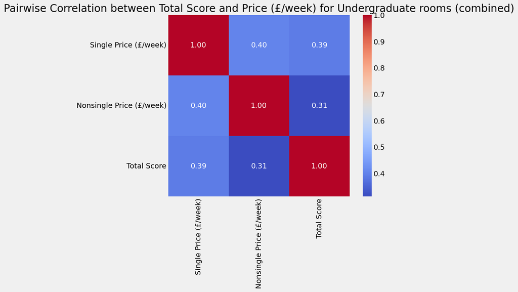

```python
## For undergraduate rooms -- single and nonsingle combined

# Select the columns of interest from each DataFrame and rename them
single_data_under = undergraduate_single_rooms[["Price (£/week)", "Total Score"]]
single_data_under.columns = ["Single Price (£/week)", "Single Total Score"]

nonsingle_data_under = undergraduate_nonsingle_rooms[["Price (£/week)", "Total Score"]]
nonsingle_data_under.columns = ["Nonsingle Price (£/week)", "Nonsingle Total Score"]

# Concatenate the two DataFrames along the columns axis
combined_data_under = pd.concat([single_data_under, nonsingle_data_under], axis=1)
combined_data_under["Total Score"] = combined_data_under[["Single Total Score", "Nonsingle Total Score"]].mean(axis=1)
combined_data_under.drop(["Single Total Score", "Nonsingle Total Score"], axis=1, inplace=True)

# Calculate correlation matrix
correlation_under = combined_data_under.corr()

# Print or visualize the correlation matrix
plt.figure(figsize=(8, 6))
sns.heatmap(correlation_under, annot=True, cmap='coolwarm', fmt=".2f", square=True)
plt.title('Pairwise Correlation between Total Score and Price (£/week) for Undergraduate rooms (combined)')
plt.show()
```

The same analysis applies to the difference in correlation between Total Score and Single Price vs Nonsingle Price (0.39 vs 0.31 respectively).

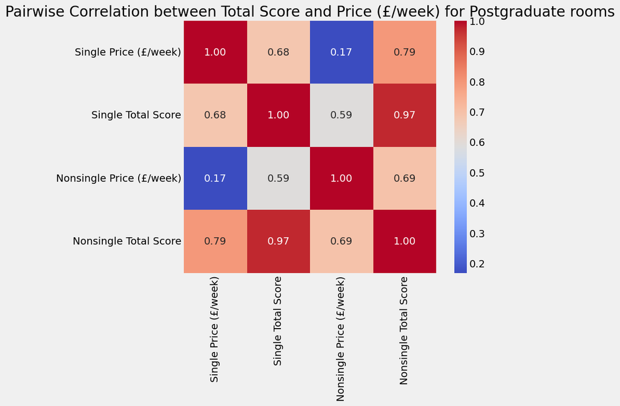

```python
## For postgraduate rooms
# Select the columns of interest from each DataFrame
single_data_postgrad = postgraduate_single_rooms[["Price (£/week)", "Total Score"]]
single_data_postgrad.columns = ["Single Price (£/week)", "Single Total Score"]

nonsingle_data_postgrad = postgraduate_nonsingle_rooms[["Price (£/week)", "Total Score"]]
nonsingle_data_postgrad.columns = ["Nonsingle Price (£/week)", "Nonsingle Total Score"]

# Concatenate the two DataFrames along the columns axis
combined_data_postgrad = pd.concat([single_data_postgrad, nonsingle_data_postgrad], axis=1)

# Calculate correlation matrix
correlation_postgrad = combined_data_postgrad.corr()

# Plot the correlation matrix
plt.figure(figsize=(8, 6))
sns.heatmap(correlation_postgrad, annot=True, cmap='coolwarm', fmt=".2f", square=True)
plt.title('Pairwise Correlation between Total Score and Price (£/week) for Postgraduate rooms')
plt.show()
```

For options available to Postgraduate students, the correlation between Total Score and Price (£/week) for single rooms is slightly lower than the correlation for non-single rooms (0.68 and 0.69 respectively). This difference is likely insginificant, which implies that the factors captured in Total Score have a very similar effect on the price for single rooms compared to non-single rooms.

The correlations for Postgraduate options are also higher compared to the correlations for Undergraduate options (i.e single: 0.68 vs 0.41; non-single: 0.69 vs 0.31). This implies that the factors captured in Total Score play a larger role in determining the price of rooms for Postgraduate options compared to Undergraduate options.

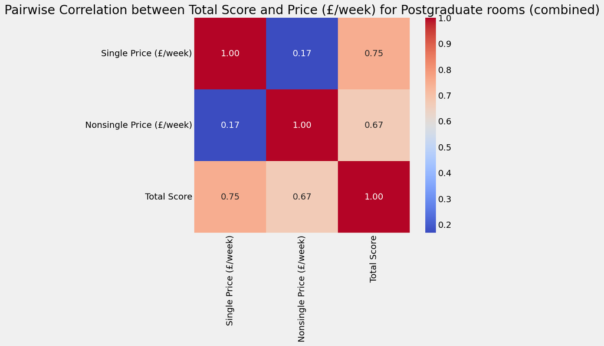

```python
## For postgraduate rooms -- single and nonsingle combined

# Select the columns of interest from each DataFrame and rename them
single_data_post = postgraduate_single_rooms[["Price (£/week)", "Total Score"]]
single_data_post.columns = ["Single Price (£/week)", "Single Total Score"]

nonsingle_data_post = postgraduate_nonsingle_rooms[["Price (£/week)", "Total Score"]]
nonsingle_data_post.columns = ["Nonsingle Price (£/week)", "Nonsingle Total Score"]

# Concatenate the two DataFrames along the columns axis
combined_data_post = pd.concat([single_data_post, nonsingle_data_post], axis=1)
combined_data_post["Total Score"] = combined_data_post[["Single Total Score", "Nonsingle Total Score"]].mean(axis=1)
combined_data_post.drop(["Single Total Score", "Nonsingle Total Score"], axis=1, inplace=True)

# Calculate correlation matrix
correlation_post = combined_data_post.corr()

# Print or visualize the correlation matrix
plt.figure(figsize=(8, 6))
sns.heatmap(correlation_post, annot=True, cmap='coolwarm', fmt=".2f", square=True)
plt.title('Pairwise Correlation between Total Score and Price (£/week) for Postgraduate rooms (combined)')
plt.show()
```

The same analysis applies to the difference in correlation between Total Score and Single Price vs Nonsingle Price (0.75 vs 0.67 respectively).

# Conclusion

This project provides a comprehensive list of all the LSE accommodation options an LSE student can choose when matriculating into LSE. In Question 1, we provide a detailed comparison of each accommodation option by identifying several differentiating factors. In Question 2, we take into account all these factors and develop a system that calculates the 'Value for Money' for each accommodation option- with this, students may be able to more easily choose their accommodation and get their money's worth. In Question 3, we investigated the relationship between price and factors such as amenities offered, room size, etc. Subsequently, we analysed if this relationship differed between accommodation available to Undergraduate students and accommodation available to Postgraduate students.

### Limitations

However, we recognise that this analysis also has some limitations:

1. The data gathered only considers accommodations offered by LSE, but students are also able to choose other private student accommodations or private housing.
2. Many halls such as International hall and Sidney Webb House offer Double studio rooms for couples or individuals that are looking for a more spacious option, however, to simplify our analysis, we assume that the population of students that are eligible to be a couple is small and thus only single individuals will be staying in such rooms.
3. We are not able to fully capture all the factors that differentiate each accommodation option (i.e thus having an effect on the price). For example, the specific location of the room within the hall.
4. For the room types that have a range of of room sizes (e.g. Urbanest Westminster Hall Single Room in room_df) and a corresponding range of prices, we simply took the upper and lower bounds (which was the data available for us to scrape) as two separate entries but ideally we should include the each of the available room sizes within the bounds as different room options.
5. Our 'Value for Money' system uses subjective judgement to decide the value of each factor, which may not always be representative of the target audience as every student has different preferences. For example, the Commute Time score was calculated purely by the time taken to travel to LSE, without factoring in deductions for any travel costs incurred.

Further analysis and information could address the first, second, third, and fourth points to produce a more robust result. For the last point, qualitative elements like surveys could be incorporated to allow for different viewpoints on valuing each of the factors.

# Reference

LSE website: Available accomodations 2024/5

https://www.lse.ac.uk/student-life/accommodation/search-accommodation?collection=lse-accommodation&sort=metaavailability